# Data Analysis Tutorial: Understanding the Global Cost of Living

Joel Gnahoui-David, Fall 2022

1. Introduction
2. Libraries and Tools
3. Dataset
4. Exploration and Data Analysis
5. Hypothesis Testing
6. Insights and Final Comments

## 1. Introduction

In recent years there has been an increasing interest in the Cost of living around the world. Some are claiming that we are in, as the [World Economic Forum](https://www.weforum.org/agenda/2022/09/cost-of-living-crisis-global-impact/) puts it, a cost of living crisis. With the increasing uncertainty of the state of the world, many have become uneasy about how their stability of life will be maintained. Mainly how the relationship between what they have to spend and how much money they are making.

In this tutorial, we will analyze and attempt to understand the relationship between cost of living and salary along with other metrics.

Our goal is to determine if around the world people are being given a fair salary that is proportionate to the cost of living.

We will be follwoing the Data Science Pipeline

1. Data collection + parsing (if necessary)
2. Data management
3. Exploratory data analysis
4. Hypothesis testing
5. Communication of insights attained

## 2. Libraries and Tools

The following Libriaries and Tools are what we will be using to perform this Data Analysis

[pandas](https://pandas.pydata.org/pandas-docs/stable/index.html) - a data analysis toolkit for building data frames

[numpy](https://docs.scipy.org/doc/numpy-1.13.0/index.html) - a package for scientific computing with special n-d arrays

[sklearn](https://scikit-learn.org/stable/index.html) - for regressions and modelling

[seaborn](https://scikit-learn.org/stable/index.html) - visually-appealing abstractions over matplotlib

[matplotlib](https://matplotlib.org/stable/users/index.html) - plotting library for graphing

[statsmodels](https://www.statsmodels.org/stable/index.html) - contains functions for statistical analysis

```python
# importing libraries
import pandas as pd
import numpy as np
import matplotlib.pyplot as plt
import seaborn as sns
import statsmodels.formula.api as smf
from sklearn.model_selection import train_test_split
from sklearn.linear_model import LinearRegression
from sklearn.ensemble import RandomForestRegressor
from sklearn.neighbors import KNeighborsRegressor
from sklearn.model_selection import RandomizedSearchCV
from sklearn.metrics import recall_score, accuracy_score, precision_score
from sklearn.metrics import classification_report, confusion_matrix
from sklearn.metrics import mean_squared_error, r2_score
```

## 3. Dataset

The objective of this tutorial is to explore and understand the Cost of Living between different countires and how they relate to each other, as well as to determine what factors play the largest role/ a method of predicting the GCL/Salary.

To this end we have obtained the following dataset from [kaggle](https://www.kaggle.com/datasets/mvieira101/global-cost-of-living)

The dataset is a csv file that contains information about the cost of living in almost 5000 cities across the world. The data was gatthered from [Numbeo](https://www.numbeo.com/cost-of-living/) which describes itself as "The world’s largest cost of living".

The kaggle page gives a explaination of what the data means and provides us with a description of each column:

city Name of the city

country Name of the country

x1 Meal, Inexpensive Restaurant (USD)

x2 Meal for 2 People, Mid-range Restaurant, Three-course (USD)

x3 McMeal at McDonalds (or Equivalent Combo Meal) (USD)

x4 Domestic Beer (0.5 liter draught, in restaurants) (USD)

x5 Imported Beer (0.33 liter bottle, in restaurants) (USD)

x6 Cappuccino (regular, in restaurants) (USD)

x7 Coke/Pepsi (0.33 liter bottle, in restaurants) (USD)

x8 Water (0.33 liter bottle, in restaurants) (USD)

x9 Milk (regular), (1 liter) (USD)

x10 Loaf of Fresh White Bread (500g) (USD)

x11 Rice (white), (1kg) (USD)

x12 Eggs (regular) (12) (USD)

x13 Local Cheese (1kg) (USD)

x14 Chicken Fillets (1kg) (USD)

x15 Beef Round (1kg) (or Equivalent Back Leg Red Meat) (USD)

x16 Apples (1kg) (USD)

x17 Banana (1kg) (USD)

x18 Oranges (1kg) (USD)

x19 Tomato (1kg) (USD)

x20 Potato (1kg) (USD)

x21 Onion (1kg) (USD)

x22 Lettuce (1 head) (USD)

x23 Water (1.5 liter bottle, at the market) (USD)

x24 Bottle of Wine (Mid-Range, at the market) (USD)

x25 Domestic Beer (0.5 liter bottle, at the market) (USD)

x26 Imported Beer (0.33 liter bottle, at the market) (USD)

x27 Cigarettes 20 Pack (Marlboro) (USD)

x28 One-way Ticket (Local Transport) (USD)

x29 Monthly Pass (Regular Price) (USD)

x30 Taxi Start (Normal Tariff) (USD)

x31 Taxi 1km (Normal Tariff) (USD)

x32 Taxi 1hour Waiting (Normal Tariff) (USD)

x33 Gasoline (1 liter) (USD)

x34 Volkswagen Golf 1.4 90 KW Trendline (Or Equivalent New Car) (USD)

x35 Toyota Corolla Sedan 1.6l 97kW Comfort (Or Equivalent New Car) (USD)

x36 Basic (Electricity, Heating, Cooling, Water, Garbage) for 85m2 Apartment (USD)

x37 1 min. of Prepaid Mobile Tariff Local (No Discounts or Plans) (USD)

x38 Internet (60 Mbps or More, Unlimited Data, Cable/ADSL) (USD)

x39 Fitness Club, Monthly Fee for 1 Adult (USD)

x40 Tennis Court Rent (1 Hour on Weekend) (USD)

x41 Cinema, International Release, 1 Seat (USD)

x42 Preschool (or Kindergarten), Full Day, Private, Monthly for 1 Child (USD)

x43 International Primary School, Yearly for 1 Child (USD)

x44 1 Pair of Jeans (Levis 501 Or Similar) (USD)

x45 1 Summer Dress in a Chain Store (Zara, H&M, …) (USD)

x46 1 Pair of Nike Running Shoes (Mid-Range) (USD)

x47 1 Pair of Men Leather Business Shoes (USD)

x48 Apartment (1 bedroom) in City Centre (USD)

x49 Apartment (1 bedroom) Outside of Centre (USD)

x50 Apartment (3 bedrooms) in City Centre (USD)

x51 Apartment (3 bedrooms) Outside of Centre (USD)

x52 Price per Square Meter to Buy Apartment in City Centre (USD)

x53 Price per Square Meter to Buy Apartment Outside of Centre (USD)

x54 Average Monthly Net Salary (After Tax) (USD)

x55 Mortgage Interest Rate in Percentages (%), Yearly, for 20 Years Fixed-Rate

data_quality 0 if Numbeo considers that more contributors are needed to increase data quality, else 1

```python
# Reading the dataset using pandas
df = pd.read_csv("cost-of-living_v2.csv")
df
```

|  | city | country | x1 | x2 | x3 | x4 | x5 | x6 | x7 | x8 | ... | x47 | x48 | x49 | x50 | x51 | x52 | x53 | x54 | x55 | data_quality |
| --- | --- | --- | --- | --- | --- | --- | --- | --- | --- | --- | --- | --- | --- | --- | --- | --- | --- | --- | --- | --- | --- |
| 0 | Seoul | South Korea | 7.68 | 53.78 | 6.15 | 3.07 | 4.99 | 3.93 | 1.48 | 0.79 | ... | 110.36 | 742.54 | 557.52 | 2669.12 | 1731.08 | 22067.70 | 10971.90 | 2689.62 | 3.47 | 1 |
| 1 | Shanghai | China | 5.69 | 39.86 | 5.69 | 1.14 | 4.27 | 3.98 | 0.53 | 0.33 | ... | 123.51 | 1091.93 | 569.88 | 2952.70 | 1561.59 | 17746.11 | 9416.35 | 1419.87 | 5.03 | 1 |
| 2 | Guangzhou | China | 4.13 | 28.47 | 4.98 | 0.85 | 1.71 | 3.54 | 0.44 | 0.33 | ... | 43.89 | 533.28 | 317.45 | 1242.24 | 688.05 | 12892.82 | 5427.45 | 1211.68 | 5.19 | 1 |
| 3 | Mumbai | India | 3.68 | 18.42 | 3.68 | 2.46 | 4.30 | 2.48 | 0.48 | 0.19 | ... | 41.17 | 522.40 | 294.05 | 1411.12 | 699.80 | 6092.45 | 2777.51 | 640.81 | 7.96 | 1 |
| 4 | Delhi | India | 4.91 | 22.11 | 4.30 | 1.84 | 3.68 | 1.77 | 0.49 | 0.19 | ... | 36.50 | 229.84 | 135.31 | 601.02 | 329.15 | 2506.73 | 1036.74 | 586.46 | 8.06 | 1 |
| ... | ... | ... | ... | ... | ... | ... | ... | ... | ... | ... | ... | ... | ... | ... | ... | ... | ... | ... | ... | ... | ... |
| 4951 | Peterborough | Australia | NaN | NaN | NaN | NaN | NaN | NaN | NaN | NaN | ... | NaN | NaN | NaN | NaN | NaN | NaN | NaN | NaN | NaN | 0 |
| 4952 | Georgetown | Australia | NaN | NaN | NaN | NaN | NaN | NaN | NaN | NaN | ... | NaN | NaN | NaN | NaN | NaN | NaN | NaN | NaN | NaN | 0 |
| 4953 | Ixtapa Zihuatanejo | Mexico | 5.16 | 30.94 | 12.89 | 0.98 | NaN | 1.80 | 0.62 | 0.41 | ... | 103.14 | 412.55 | 257.84 | 515.69 | 412.55 | NaN | NaN | NaN | NaN | 0 |
| 4954 | Iqaluit | Canada | 29.65 | 74.27 | 13.71 | 6.67 | 8.89 | 3.71 | 3.52 | 4.08 | ... | NaN | NaN | NaN | 2964.60 | 2964.60 | NaN | NaN | NaN | 6.53 | 0 |
| 4955 | Neiafu | Tonga | NaN | 29.79 | 10.64 | 10.64 | NaN | NaN | 2.13 | 2.13 | ... | NaN | NaN | NaN | NaN | NaN | NaN | NaN | NaN | NaN | 0 |

4956 rows × 58 columns

We can use the describe function to view some basic statistical details like percentile, mean, std etc.

```python
df.describe()
```

|  | x1 | x2 | x3 | x4 | x5 | x6 | x7 | x8 | x9 | x10 | ... | x47 | x48 | x49 | x50 | x51 | x52 | x53 | x54 | x55 | data_quality |
| --- | --- | --- | --- | --- | --- | --- | --- | --- | --- | --- | --- | --- | --- | --- | --- | --- | --- | --- | --- | --- | --- |
| count | 4528.000000 | 4505.000000 | 4622.000000 | 4460.000000 | 4516.000000 | 4612.000000 | 4511.000000 | 4640.000000 | 4578.000000 | 4543.000000 | ... | 4403.000000 | 3593.000000 | 3525.000000 | 3476.000000 | 3444.000000 | 2729.000000 | 2653.000000 | 3524.000000 | 3950.000000 | 4956.000000 |
| mean | 10.346705 | 43.357811 | 6.929697 | 3.379774 | 3.942465 | 2.754952 | 1.523873 | 1.119804 | 1.148554 | 1.612855 | ... | 85.976357 | 711.574943 | 560.159957 | 1253.982914 | 974.082854 | 3235.270854 | 2341.933102 | 1821.186305 | 6.518030 | 0.186239 |
| std | 7.157058 | 25.528312 | 2.704435 | 2.105957 | 2.100146 | 1.358821 | 0.907025 | 0.755257 | 0.517186 | 1.089164 | ... | 40.434524 | 648.869301 | 527.492342 | 1219.395297 | 921.331271 | 6258.792897 | 3570.623878 | 1631.465580 | 5.413828 | 0.389339 |
| min | 0.450000 | 3.250000 | 1.080000 | 0.330000 | 0.310000 | 0.220000 | 0.110000 | 0.070000 | 0.260000 | 0.050000 | ... | 7.600000 | 21.700000 | 12.200000 | 61.510000 | 27.120000 | 111.010000 | 49.240000 | 18.000000 | 0.780000 | 0.000000 |
| 25% | 4.310000 | 22.440000 | 4.980000 | 1.600000 | 2.200000 | 1.580000 | 0.770000 | 0.480000 | 0.830000 | 0.780000 | ... | 58.430000 | 256.240000 | 171.050000 | 465.200000 | 325.710000 | 1120.110000 | 790.310000 | 478.980000 | 3.000000 | 0.000000 |
| 50% | 9.600000 | 40.000000 | 6.990000 | 3.000000 | 3.690000 | 2.630000 | 1.480000 | 1.050000 | 1.045000 | 1.320000 | ... | 84.260000 | 526.870000 | 403.940000 | 921.075000 | 712.830000 | 2107.490000 | 1580.620000 | 1290.840000 | 5.200000 | 0.000000 |
| 75% | 15.000000 | 60.000000 | 8.500000 | 5.000000 | 5.270000 | 3.770000 | 2.110000 | 1.580000 | 1.320000 | 2.200000 | ... | 106.770000 | 992.610000 | 790.310000 | 1710.225000 | 1369.870000 | 3843.380000 | 2798.250000 | 2770.855000 | 8.330000 | 0.000000 |
| max | 57.140000 | 213.690000 | 22.130000 | 20.600000 | 17.500000 | 10.000000 | 8.000000 | 5.850000 | 6.810000 | 8.820000 | ... | 542.740000 | 12608.830000 | 8989.370000 | 27397.380000 | 17868.180000 | 240963.670000 | 80321.220000 | 12821.400000 | 61.330000 | 1.000000 |

8 rows × 56 columns

Before we can continue with our analysis we need to clean up the dataset.

The first thing we can do is check for any null values using the isnull() function

```python
df.isnull().values.any()
```

```
True
```

From this we can see that we do contain null values, which will need to be handled before we can proceed.

First we will need to get an overview of how each input feature is correlated using the corr() function and seaborn's heatmap functionality.

|  | x1 | x2 | x3 | x4 | x5 | x6 | x7 | x8 | x9 | x10 | ... | x47 | x48 | x49 | x50 | x51 | x52 | x53 | x54 | x55 | data_quality |
| --- | --- | --- | --- | --- | --- | --- | --- | --- | --- | --- | --- | --- | --- | --- | --- | --- | --- | --- | --- | --- | --- |
| x1 | 1.000000 | 0.787133 | 0.700265 | 0.671351 | 0.616461 | 0.632536 | 0.744296 | 0.697386 | 0.139099 | 0.622231 | ... | 0.510627 | 0.615323 | 0.658256 | 0.557003 | 0.632815 | 0.190151 | 0.271267 | 0.697417 | -0.381823 | 0.053349 |
| x2 | 0.787133 | 1.000000 | 0.718105 | 0.698378 | 0.642865 | 0.655371 | 0.769949 | 0.740840 | 0.222924 | 0.622224 | ... | 0.552658 | 0.623417 | 0.651899 | 0.589836 | 0.640696 | 0.240004 | 0.337908 | 0.693948 | -0.403753 | 0.125896 |
| x3 | 0.700265 | 0.718105 | 1.000000 | 0.650093 | 0.584583 | 0.585797 | 0.738213 | 0.722785 | 0.227091 | 0.584919 | ... | 0.507945 | 0.508011 | 0.533690 | 0.456913 | 0.508525 | 0.247241 | 0.322331 | 0.606278 | -0.379621 | 0.076124 |
| x4 | 0.671351 | 0.698378 | 0.650093 | 1.000000 | 0.816765 | 0.666698 | 0.693952 | 0.660362 | 0.164818 | 0.592242 | ... | 0.442152 | 0.592668 | 0.626555 | 0.520789 | 0.587385 | 0.232883 | 0.315791 | 0.682828 | -0.419605 | 0.091968 |
| x5 | 0.616461 | 0.642865 | 0.584583 | 0.816765 | 1.000000 | 0.715239 | 0.593185 | 0.562202 | 0.182607 | 0.633279 | ... | 0.386164 | 0.607882 | 0.630377 | 0.544862 | 0.606742 | 0.234419 | 0.303469 | 0.667784 | -0.327730 | 0.075006 |
| x6 | 0.632536 | 0.655371 | 0.585797 | 0.666698 | 0.715239 | 1.000000 | 0.614581 | 0.620798 | 0.249647 | 0.716695 | ... | 0.426496 | 0.645768 | 0.678310 | 0.594428 | 0.652725 | 0.209372 | 0.274923 | 0.743677 | -0.320521 | 0.050225 |
| x7 | 0.744296 | 0.769949 | 0.738213 | 0.693952 | 0.593185 | 0.614581 | 1.000000 | 0.864045 | 0.134981 | 0.614025 | ... | 0.543205 | 0.546898 | 0.586993 | 0.503820 | 0.563916 | 0.221841 | 0.297281 | 0.663668 | -0.462790 | 0.075022 |
| x8 | 0.697386 | 0.740840 | 0.722785 | 0.660362 | 0.562202 | 0.620798 | 0.864045 | 1.000000 | 0.112019 | 0.609887 | ... | 0.519553 | 0.555923 | 0.585581 | 0.522027 | 0.569446 | 0.237654 | 0.327740 | 0.697286 | -0.447545 | 0.062184 |
| x9 | 0.139099 | 0.222924 | 0.227091 | 0.164818 | 0.182607 | 0.249647 | 0.134981 | 0.112019 | 1.000000 | 0.237035 | ... | 0.268338 | 0.149859 | 0.136331 | 0.186136 | 0.158810 | 0.218804 | 0.244836 | 0.116801 | -0.106681 | 0.083020 |
| x10 | 0.622231 | 0.622224 | 0.584919 | 0.592242 | 0.633279 | 0.716695 | 0.614025 | 0.609887 | 0.237035 | 1.000000 | ... | 0.423268 | 0.623655 | 0.666877 | 0.580028 | 0.642906 | 0.187154 | 0.259004 | 0.716963 | -0.295694 | 0.026190 |
| x11 | 0.539335 | 0.511819 | 0.433007 | 0.492931 | 0.537090 | 0.616368 | 0.473940 | 0.457919 | 0.177139 | 0.664725 | ... | 0.378919 | 0.569889 | 0.601532 | 0.536095 | 0.589259 | 0.138095 | 0.193292 | 0.607866 | -0.210760 | -0.019761 |
| x12 | 0.664373 | 0.692471 | 0.669963 | 0.630149 | 0.564701 | 0.614051 | 0.704643 | 0.667848 | 0.339591 | 0.646953 | ... | 0.491111 | 0.546974 | 0.577544 | 0.505303 | 0.555409 | 0.231362 | 0.315355 | 0.632514 | -0.374969 | 0.085881 |
| x13 | 0.424392 | 0.452794 | 0.465449 | 0.390624 | 0.355190 | 0.390877 | 0.465904 | 0.446686 | 0.273350 | 0.450194 | ... | 0.434053 | 0.354346 | 0.368523 | 0.355092 | 0.372427 | 0.239739 | 0.287238 | 0.429517 | -0.319191 | 0.069699 |
| x14 | 0.665952 | 0.665241 | 0.637518 | 0.608717 | 0.572499 | 0.617276 | 0.697162 | 0.654460 | 0.182550 | 0.644975 | ... | 0.473278 | 0.570590 | 0.597813 | 0.517490 | 0.573926 | 0.219699 | 0.291663 | 0.656552 | -0.346588 | 0.058847 |
| x15 | 0.518632 | 0.564407 | 0.573507 | 0.506353 | 0.423156 | 0.481039 | 0.607103 | 0.601488 | 0.243507 | 0.501418 | ... | 0.479067 | 0.408493 | 0.427413 | 0.394004 | 0.420578 | 0.214358 | 0.271734 | 0.538455 | -0.346968 | 0.087309 |
| x16 | 0.420380 | 0.411911 | 0.387318 | 0.413725 | 0.483926 | 0.588596 | 0.369094 | 0.386075 | 0.263571 | 0.583880 | ... | 0.274426 | 0.508662 | 0.517070 | 0.481895 | 0.520777 | 0.175534 | 0.234412 | 0.560253 | -0.183666 | -0.038468 |
| x17 | 0.375257 | 0.391888 | 0.386504 | 0.338282 | 0.313668 | 0.349577 | 0.410617 | 0.383039 | 0.349484 | 0.324533 | ... | 0.399647 | 0.302939 | 0.294175 | 0.301997 | 0.315004 | 0.161562 | 0.230341 | 0.323455 | -0.239570 | 0.020248 |
| x18 | 0.515754 | 0.477237 | 0.415143 | 0.465883 | 0.536700 | 0.623318 | 0.446160 | 0.440298 | 0.229066 | 0.608436 | ... | 0.354537 | 0.495307 | 0.515777 | 0.473964 | 0.509391 | 0.177846 | 0.233397 | 0.577252 | -0.253435 | -0.020095 |
| x19 | 0.577963 | 0.561062 | 0.477150 | 0.502722 | 0.535542 | 0.623217 | 0.527416 | 0.521573 | 0.180373 | 0.639681 | ... | 0.399157 | 0.561043 | 0.588227 | 0.501604 | 0.561848 | 0.157105 | 0.219832 | 0.626356 | -0.286098 | -0.016791 |
| x20 | 0.501148 | 0.476485 | 0.443456 | 0.447513 | 0.502842 | 0.583807 | 0.449723 | 0.458435 | 0.260350 | 0.613071 | ... | 0.332802 | 0.533721 | 0.544391 | 0.492996 | 0.539540 | 0.168200 | 0.236755 | 0.570835 | -0.231463 | -0.029227 |
| x21 | 0.523620 | 0.494303 | 0.452491 | 0.471406 | 0.519864 | 0.597099 | 0.470858 | 0.465235 | 0.233224 | 0.653683 | ... | 0.322374 | 0.552460 | 0.573770 | 0.525665 | 0.567481 | 0.160061 | 0.225313 | 0.605192 | -0.233716 | -0.034500 |
| x22 | 0.532839 | 0.569229 | 0.520282 | 0.518331 | 0.525718 | 0.584420 | 0.503643 | 0.529995 | 0.333933 | 0.607738 | ... | 0.430604 | 0.516276 | 0.514800 | 0.463824 | 0.502813 | 0.145712 | 0.225847 | 0.576527 | -0.251027 | 0.029368 |
| x23 | 0.569198 | 0.558750 | 0.481528 | 0.541478 | 0.600625 | 0.683022 | 0.472422 | 0.499978 | 0.211144 | 0.672720 | ... | 0.333717 | 0.581910 | 0.618641 | 0.530160 | 0.598697 | 0.152129 | 0.219507 | 0.636837 | -0.194482 | -0.001278 |
| x24 | 0.351206 | 0.384850 | 0.341213 | 0.472192 | 0.569759 | 0.569506 | 0.258701 | 0.278487 | 0.337662 | 0.512076 | ... | 0.233983 | 0.398422 | 0.411931 | 0.380067 | 0.398476 | 0.194928 | 0.237916 | 0.454460 | -0.168507 | 0.021889 |
| x25 | 0.461349 | 0.468444 | 0.403384 | 0.582097 | 0.644741 | 0.553933 | 0.376864 | 0.356464 | 0.165697 | 0.491191 | ... | 0.242478 | 0.460056 | 0.471345 | 0.395590 | 0.451622 | 0.121195 | 0.177035 | 0.518738 | -0.205496 | 0.069511 |
| x26 | 0.329366 | 0.315673 | 0.299660 | 0.438807 | 0.540834 | 0.431649 | 0.241402 | 0.213570 | 0.207735 | 0.350222 | ... | 0.195174 | 0.292053 | 0.297578 | 0.276805 | 0.294436 | 0.086381 | 0.104845 | 0.336926 | -0.115318 | 0.058764 |
| x27 | 0.627678 | 0.644465 | 0.555889 | 0.635434 | 0.584761 | 0.539153 | 0.603832 | 0.594384 | 0.209873 | 0.450110 | ... | 0.370664 | 0.516815 | 0.536491 | 0.454576 | 0.514942 | 0.155575 | 0.235167 | 0.589283 | -0.395359 | 0.079434 |
| x28 | 0.582769 | 0.626361 | 0.539219 | 0.577139 | 0.489884 | 0.528174 | 0.620203 | 0.636827 | 0.133792 | 0.475326 | ... | 0.381780 | 0.508819 | 0.539574 | 0.440595 | 0.522349 | 0.180540 | 0.252279 | 0.650855 | -0.429594 | 0.024232 |
| x29 | 0.513656 | 0.556303 | 0.461032 | 0.531637 | 0.454758 | 0.481493 | 0.485028 | 0.507310 | 0.189715 | 0.420101 | ... | 0.343599 | 0.501329 | 0.508959 | 0.426648 | 0.490704 | 0.189526 | 0.261534 | 0.588117 | -0.333694 | 0.031904 |
| x30 | 0.532705 | 0.580194 | 0.578830 | 0.517246 | 0.451234 | 0.431578 | 0.569895 | 0.543905 | 0.190364 | 0.448743 | ... | 0.427350 | 0.363234 | 0.380068 | 0.330313 | 0.364081 | 0.161045 | 0.254692 | 0.445509 | -0.367972 | 0.048176 |
| x31 | 0.510908 | 0.560771 | 0.574438 | 0.469642 | 0.399456 | 0.467810 | 0.578052 | 0.583701 | 0.202714 | 0.478053 | ... | 0.399774 | 0.401678 | 0.419761 | 0.371155 | 0.407333 | 0.180347 | 0.271193 | 0.541140 | -0.321203 | 0.051166 |
| x32 | 0.655562 | 0.702710 | 0.676028 | 0.647089 | 0.546740 | 0.557935 | 0.718908 | 0.724815 | 0.156420 | 0.580926 | ... | 0.478712 | 0.497652 | 0.528424 | 0.453079 | 0.495415 | 0.338889 | 0.353458 | 0.627716 | -0.435767 | 0.077261 |
| x33 | 0.404555 | 0.446270 | 0.456842 | 0.405787 | 0.232211 | 0.173689 | 0.557846 | 0.524284 | 0.055572 | 0.197765 | ... | 0.314985 | 0.192002 | 0.212851 | 0.163484 | 0.195428 | 0.146998 | 0.195427 | 0.287388 | -0.531900 | 0.131109 |
| x34 | 0.187169 | 0.226167 | 0.228976 | 0.178508 | 0.146629 | 0.185488 | 0.205937 | 0.181347 | 0.202707 | 0.137680 | ... | 0.295997 | 0.161051 | 0.155699 | 0.169825 | 0.151637 | 0.031482 | 0.053215 | 0.113249 | 0.027823 | 0.074724 |
| x35 | 0.147601 | 0.166534 | 0.208789 | 0.113786 | 0.074934 | 0.085602 | 0.172258 | 0.148995 | 0.124195 | 0.067023 | ... | 0.265738 | 0.083766 | 0.077358 | 0.088076 | 0.069825 | 0.038973 | 0.037779 | 0.047298 | 0.094696 | 0.085075 |
| x36 | 0.538796 | 0.536971 | 0.484908 | 0.474442 | 0.404926 | 0.450255 | 0.609516 | 0.561824 | 0.090151 | 0.401814 | ... | 0.404963 | 0.378452 | 0.401362 | 0.343247 | 0.390569 | 0.190672 | 0.228561 | 0.469536 | -0.434818 | 0.064650 |
| x37 | 0.312701 | 0.316272 | 0.300300 | 0.252359 | 0.224372 | 0.234380 | 0.327957 | 0.287450 | 0.180674 | 0.281515 | ... | 0.203228 | 0.245251 | 0.259291 | 0.237229 | 0.265018 | 0.114885 | 0.155139 | 0.293174 | -0.218357 | 0.063595 |
| x38 | -0.008607 | 0.008489 | 0.047709 | 0.010215 | -0.004628 | 0.016512 | 0.016760 | 0.003335 | 0.046324 | -0.000514 | ... | 0.014623 | -0.001619 | 0.005165 | 0.012432 | 0.011385 | 0.251222 | 0.319162 | -0.009940 | 0.020774 | -0.007502 |
| x39 | 0.363016 | 0.425414 | 0.377511 | 0.324840 | 0.308803 | 0.335491 | 0.344313 | 0.322108 | 0.323142 | 0.327648 | ... | 0.374879 | 0.394819 | 0.377080 | 0.498920 | 0.423551 | 0.273373 | 0.353798 | 0.343052 | -0.229679 | 0.071065 |
| x40 | 0.328329 | 0.388261 | 0.376072 | 0.309552 | 0.261437 | 0.308603 | 0.338300 | 0.330552 | 0.188123 | 0.302785 | ... | 0.331230 | 0.246971 | 0.244798 | 0.235157 | 0.246487 | 0.090523 | 0.123980 | 0.312588 | -0.168572 | 0.100194 |
| x41 | 0.709345 | 0.753918 | 0.684660 | 0.699999 | 0.633799 | 0.713301 | 0.716324 | 0.720514 | 0.195945 | 0.645029 | ... | 0.504296 | 0.642165 | 0.657024 | 0.574243 | 0.630290 | 0.221314 | 0.312834 | 0.770659 | -0.492915 | 0.077989 |
| x42 | 0.640503 | 0.616476 | 0.528432 | 0.580018 | 0.557684 | 0.626257 | 0.561769 | 0.576102 | 0.101256 | 0.597851 | ... | 0.381022 | 0.643845 | 0.681257 | 0.624850 | 0.651780 | 0.231076 | 0.294206 | 0.717455 | -0.300228 | 0.099153 |
| x43 | 0.504870 | 0.499441 | 0.389930 | 0.433851 | 0.445348 | 0.541684 | 0.443360 | 0.455718 | 0.185244 | 0.530130 | ... | 0.360671 | 0.508869 | 0.543961 | 0.472957 | 0.532260 | 0.195727 | 0.259884 | 0.581067 | -0.288056 | 0.066345 |
| x44 | 0.403080 | 0.456375 | 0.443769 | 0.339847 | 0.187987 | 0.191748 | 0.511345 | 0.461624 | 0.172103 | 0.165996 | ... | 0.562287 | 0.176647 | 0.188167 | 0.177763 | 0.181705 | 0.130698 | 0.177446 | 0.252405 | -0.348038 | 0.171558 |
| x45 | 0.253737 | 0.289338 | 0.300601 | 0.196745 | 0.194958 | 0.217556 | 0.261965 | 0.231550 | 0.194710 | 0.187793 | ... | 0.395824 | 0.181434 | 0.187439 | 0.194467 | 0.184036 | 0.079487 | 0.091175 | 0.177911 | -0.037945 | 0.078090 |
| x46 | 0.275378 | 0.314899 | 0.305299 | 0.195290 | 0.181490 | 0.227504 | 0.284817 | 0.251934 | 0.232205 | 0.188469 | ... | 0.592513 | 0.206540 | 0.200997 | 0.230614 | 0.189210 | 0.070724 | 0.090559 | 0.159297 | 0.006498 | 0.079083 |
| x47 | 0.510627 | 0.552658 | 0.507945 | 0.442152 | 0.386164 | 0.426496 | 0.543205 | 0.519553 | 0.268338 | 0.423268 | ... | 1.000000 | 0.385617 | 0.389520 | 0.410521 | 0.385335 | 0.186794 | 0.249608 | 0.427181 | -0.271838 | 0.097701 |
| x48 | 0.615323 | 0.623417 | 0.508011 | 0.592668 | 0.607882 | 0.645768 | 0.546898 | 0.555923 | 0.149859 | 0.623655 | ... | 0.385617 | 1.000000 | 0.945210 | 0.895985 | 0.921416 | 0.252915 | 0.328297 | 0.732269 | -0.266614 | 0.090034 |
| x49 | 0.658256 | 0.651899 | 0.533690 | 0.626555 | 0.630377 | 0.678310 | 0.586993 | 0.585581 | 0.136331 | 0.666877 | ... | 0.389520 | 0.945210 | 1.000000 | 0.852954 | 0.928118 | 0.237534 | 0.316982 | 0.756663 | -0.286649 | 0.069866 |
| x50 | 0.557003 | 0.589836 | 0.456913 | 0.520789 | 0.544862 | 0.594428 | 0.503820 | 0.522027 | 0.186136 | 0.580028 | ... | 0.410521 | 0.895985 | 0.852954 | 1.000000 | 0.921010 | 0.310262 | 0.394955 | 0.652513 | -0.215854 | 0.102657 |
| x51 | 0.632815 | 0.640696 | 0.508525 | 0.587385 | 0.606742 | 0.652725 | 0.563916 | 0.569446 | 0.158810 | 0.642906 | ... | 0.385335 | 0.921416 | 0.928118 | 0.921010 | 1.000000 | 0.261945 | 0.355600 | 0.730072 | -0.256152 | 0.073572 |
| x52 | 0.190151 | 0.240004 | 0.247241 | 0.232883 | 0.234419 | 0.209372 | 0.221841 | 0.237654 | 0.218804 | 0.187154 | ... | 0.186794 | 0.252915 | 0.237534 | 0.310262 | 0.261945 | 1.000000 | 0.832690 | 0.216737 | -0.114912 | 0.081059 |
| x53 | 0.271267 | 0.337908 | 0.322331 | 0.315791 | 0.303469 | 0.274923 | 0.297281 | 0.327740 | 0.244836 | 0.259004 | ... | 0.249608 | 0.328297 | 0.316982 | 0.394955 | 0.355600 | 0.832690 | 1.000000 | 0.307287 | -0.156649 | 0.093708 |
| x54 | 0.697417 | 0.693948 | 0.606278 | 0.682828 | 0.667784 | 0.743677 | 0.663668 | 0.697286 | 0.116801 | 0.716963 | ... | 0.427181 | 0.732269 | 0.756663 | 0.652513 | 0.730072 | 0.216737 | 0.307287 | 1.000000 | -0.400285 | 0.060424 |
| x55 | -0.381823 | -0.403753 | -0.379621 | -0.419605 | -0.327730 | -0.320521 | -0.462790 | -0.447545 | -0.106681 | -0.295694 | ... | -0.271838 | -0.266614 | -0.286649 | -0.215854 | -0.256152 | -0.114912 | -0.156649 | -0.400285 | 1.000000 | -0.019747 |
| data_quality | 0.053349 | 0.125896 | 0.076124 | 0.091968 | 0.075006 | 0.050225 | 0.075022 | 0.062184 | 0.083020 | 0.026190 | ... | 0.097701 | 0.090034 | 0.069866 | 0.102657 | 0.073572 | 0.081059 | 0.093708 | 0.060424 | -0.019747 | 1.000000 |

56 rows × 56 columns

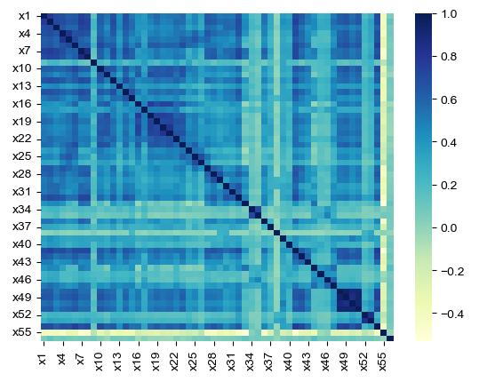

```python
#Getting an overview of how each input feature is correlated
df.corr()
#Translating the above correlation table into a heatmap to get a better sense of intuition
sns.heatmap(df.corr(), cmap="YlGnBu")
sns.set(rc={'figure.figsize':(10,10)})
df.corr()
```

It is important that we make sure there is no bias in the data towards missing values. If so, it could make the models less accurate because they will not be able to successfully predict the target because it cannot account for the biases that might've caused the missing data.

|  | x1 | x2 | x3 | x4 | x5 | x6 | x7 | x8 | x9 | x10 | ... | x47 | x48 | x49 | x50 | x51 | x52 | x53 | x54 | x55 | data_quality |
| --- | --- | --- | --- | --- | --- | --- | --- | --- | --- | --- | --- | --- | --- | --- | --- | --- | --- | --- | --- | --- | --- |
| x1 | 1.000000 | 0.876708 | 0.785875 | 0.715638 | 0.626156 | 0.674233 | 0.804164 | 0.768857 | 0.218020 | 0.677909 | ... | 0.575052 | 0.687399 | 0.727388 | 0.682242 | 0.751741 | 0.318646 | 0.297361 | 0.777048 | -0.473564 | NaN |
| x2 | 0.876708 | 1.000000 | 0.817181 | 0.767804 | 0.663300 | 0.711617 | 0.817312 | 0.804126 | 0.297418 | 0.696914 | ... | 0.608210 | 0.690525 | 0.714544 | 0.712487 | 0.757864 | 0.380647 | 0.351261 | 0.765232 | -0.507632 | NaN |
| x3 | 0.785875 | 0.817181 | 1.000000 | 0.725431 | 0.618268 | 0.627528 | 0.804421 | 0.792846 | 0.260796 | 0.660598 | ... | 0.601677 | 0.570772 | 0.603978 | 0.567694 | 0.619858 | 0.353222 | 0.349224 | 0.686257 | -0.478688 | NaN |
| x4 | 0.715638 | 0.767804 | 0.725431 | 1.000000 | 0.870603 | 0.683761 | 0.702684 | 0.671719 | 0.222226 | 0.616465 | ... | 0.477484 | 0.643644 | 0.665521 | 0.617745 | 0.665750 | 0.421286 | 0.376150 | 0.728066 | -0.493007 | NaN |
| x5 | 0.626156 | 0.663300 | 0.618268 | 0.870603 | 1.000000 | 0.731452 | 0.547606 | 0.526181 | 0.256214 | 0.662730 | ... | 0.403280 | 0.660072 | 0.672431 | 0.645501 | 0.678524 | 0.466634 | 0.417525 | 0.714103 | -0.374026 | NaN |
| x6 | 0.674233 | 0.711617 | 0.627528 | 0.683761 | 0.731452 | 1.000000 | 0.595725 | 0.618795 | 0.332630 | 0.749262 | ... | 0.490754 | 0.728448 | 0.738031 | 0.733789 | 0.760428 | 0.330454 | 0.287996 | 0.796731 | -0.381095 | NaN |
| x7 | 0.804164 | 0.817312 | 0.804421 | 0.702684 | 0.547606 | 0.595725 | 1.000000 | 0.910771 | 0.155797 | 0.649140 | ... | 0.612013 | 0.559775 | 0.603253 | 0.564450 | 0.623745 | 0.322366 | 0.289495 | 0.720109 | -0.575504 | NaN |
| x8 | 0.768857 | 0.804126 | 0.792846 | 0.671719 | 0.526181 | 0.618795 | 0.910771 | 1.000000 | 0.142457 | 0.644720 | ... | 0.582863 | 0.577135 | 0.613280 | 0.582988 | 0.641670 | 0.351153 | 0.328673 | 0.738980 | -0.548474 | NaN |
| x9 | 0.218020 | 0.297418 | 0.260796 | 0.222226 | 0.256214 | 0.332630 | 0.155797 | 0.142457 | 1.000000 | 0.292749 | ... | 0.309675 | 0.214212 | 0.190469 | 0.283941 | 0.264894 | 0.292226 | 0.253025 | 0.146708 | -0.126663 | NaN |
| x10 | 0.677909 | 0.696914 | 0.660598 | 0.616465 | 0.662730 | 0.749262 | 0.649140 | 0.644720 | 0.292749 | 1.000000 | ... | 0.484567 | 0.709010 | 0.733443 | 0.731963 | 0.769328 | 0.323999 | 0.273029 | 0.772305 | -0.350398 | NaN |
| x11 | 0.600999 | 0.568385 | 0.496626 | 0.504852 | 0.559881 | 0.672521 | 0.508884 | 0.488331 | 0.265927 | 0.763133 | ... | 0.530955 | 0.654266 | 0.673367 | 0.678582 | 0.702197 | 0.239943 | 0.197832 | 0.689226 | -0.213668 | NaN |
| x12 | 0.750255 | 0.776204 | 0.759628 | 0.679649 | 0.605021 | 0.665329 | 0.756041 | 0.726653 | 0.353600 | 0.723925 | ... | 0.587433 | 0.600538 | 0.628121 | 0.626864 | 0.665770 | 0.381491 | 0.346283 | 0.695709 | -0.467276 | NaN |
| x13 | 0.508411 | 0.541651 | 0.565687 | 0.421920 | 0.360526 | 0.451935 | 0.582389 | 0.523095 | 0.338902 | 0.534177 | ... | 0.571854 | 0.401809 | 0.411233 | 0.451995 | 0.457737 | 0.334986 | 0.265831 | 0.469700 | -0.384747 | NaN |
| x14 | 0.747486 | 0.768550 | 0.756839 | 0.655931 | 0.611106 | 0.673921 | 0.758771 | 0.742762 | 0.243845 | 0.752381 | ... | 0.582316 | 0.644741 | 0.671651 | 0.666434 | 0.707058 | 0.357995 | 0.307148 | 0.755122 | -0.422906 | NaN |
| x15 | 0.588477 | 0.637674 | 0.669143 | 0.542454 | 0.426699 | 0.500915 | 0.685294 | 0.675159 | 0.328001 | 0.534095 | ... | 0.563343 | 0.416336 | 0.438475 | 0.460221 | 0.487665 | 0.376136 | 0.305005 | 0.564966 | -0.403692 | NaN |
| x16 | 0.533074 | 0.546722 | 0.486185 | 0.508200 | 0.602301 | 0.693225 | 0.449931 | 0.457025 | 0.324289 | 0.761322 | ... | 0.347817 | 0.634218 | 0.631747 | 0.686766 | 0.692713 | 0.326619 | 0.282682 | 0.684743 | -0.247027 | NaN |
| x17 | 0.445712 | 0.528438 | 0.494578 | 0.426590 | 0.365258 | 0.446253 | 0.480777 | 0.432566 | 0.406291 | 0.430903 | ... | 0.593474 | 0.362862 | 0.351250 | 0.417539 | 0.409437 | 0.306681 | 0.265438 | 0.395895 | -0.240132 | NaN |
| x18 | 0.586735 | 0.578467 | 0.452849 | 0.513698 | 0.594681 | 0.700809 | 0.478796 | 0.486192 | 0.287322 | 0.737454 | ... | 0.423862 | 0.633586 | 0.639273 | 0.666155 | 0.680410 | 0.298597 | 0.255097 | 0.705919 | -0.311174 | NaN |
| x19 | 0.647540 | 0.648474 | 0.512289 | 0.530037 | 0.551220 | 0.661837 | 0.566471 | 0.554826 | 0.220894 | 0.710535 | ... | 0.457905 | 0.658075 | 0.679453 | 0.674697 | 0.706446 | 0.263412 | 0.219307 | 0.710214 | -0.342086 | NaN |
| x20 | 0.591939 | 0.599091 | 0.505536 | 0.486982 | 0.544602 | 0.664999 | 0.513695 | 0.519448 | 0.363908 | 0.771288 | ... | 0.414625 | 0.644093 | 0.641053 | 0.700922 | 0.707806 | 0.286691 | 0.247960 | 0.691276 | -0.289773 | NaN |
| x21 | 0.579807 | 0.571801 | 0.487849 | 0.481097 | 0.553739 | 0.640403 | 0.496387 | 0.487142 | 0.327220 | 0.766466 | ... | 0.404343 | 0.630606 | 0.639623 | 0.681206 | 0.691973 | 0.269239 | 0.230869 | 0.680450 | -0.279088 | NaN |
| x22 | 0.580988 | 0.620861 | 0.585070 | 0.551476 | 0.583002 | 0.610712 | 0.519619 | 0.545152 | 0.419428 | 0.675827 | ... | 0.515506 | 0.560965 | 0.570913 | 0.587245 | 0.613195 | 0.280360 | 0.267308 | 0.628897 | -0.287248 | NaN |
| x23 | 0.623971 | 0.619537 | 0.516619 | 0.551368 | 0.634134 | 0.722205 | 0.477151 | 0.512057 | 0.245495 | 0.724926 | ... | 0.360912 | 0.655358 | 0.680379 | 0.661831 | 0.706082 | 0.211777 | 0.188257 | 0.702970 | -0.245538 | NaN |
| x24 | 0.351867 | 0.399326 | 0.335936 | 0.514522 | 0.665962 | 0.611229 | 0.214040 | 0.235297 | 0.369763 | 0.553251 | ... | 0.221101 | 0.473994 | 0.471904 | 0.516109 | 0.512760 | 0.418040 | 0.352225 | 0.495995 | -0.169735 | NaN |
| x25 | 0.467991 | 0.464911 | 0.395129 | 0.616589 | 0.708211 | 0.580181 | 0.327760 | 0.309450 | 0.218446 | 0.488957 | ... | 0.243569 | 0.500068 | 0.512426 | 0.489079 | 0.526350 | 0.162254 | 0.147111 | 0.566363 | -0.210642 | NaN |
| x26 | 0.293163 | 0.297488 | 0.277189 | 0.482802 | 0.590950 | 0.448521 | 0.177168 | 0.169492 | 0.242310 | 0.365002 | ... | 0.173200 | 0.347306 | 0.340960 | 0.343049 | 0.360151 | 0.083792 | 0.059914 | 0.382128 | -0.109746 | NaN |
| x27 | 0.653316 | 0.652432 | 0.552653 | 0.644818 | 0.571550 | 0.546230 | 0.556666 | 0.584986 | 0.220051 | 0.438117 | ... | 0.344197 | 0.537771 | 0.567892 | 0.522622 | 0.579154 | 0.247099 | 0.233142 | 0.651121 | -0.445751 | NaN |
| x28 | 0.702324 | 0.730587 | 0.634225 | 0.663210 | 0.535054 | 0.597387 | 0.727989 | 0.749906 | 0.147616 | 0.535854 | ... | 0.437700 | 0.576495 | 0.615668 | 0.558206 | 0.622516 | 0.337269 | 0.305034 | 0.726461 | -0.541077 | NaN |
| x29 | 0.639933 | 0.659508 | 0.561099 | 0.627192 | 0.552410 | 0.594615 | 0.597987 | 0.619123 | 0.221565 | 0.504448 | ... | 0.385642 | 0.630158 | 0.643888 | 0.615538 | 0.656709 | 0.381800 | 0.337753 | 0.687508 | -0.430273 | NaN |
| x30 | 0.639852 | 0.693741 | 0.675728 | 0.625909 | 0.513241 | 0.500351 | 0.695525 | 0.641899 | 0.233419 | 0.511951 | ... | 0.497936 | 0.430242 | 0.450479 | 0.431535 | 0.461846 | 0.282715 | 0.253812 | 0.519642 | -0.481198 | NaN |
| x31 | 0.606236 | 0.637779 | 0.628048 | 0.472144 | 0.383600 | 0.517330 | 0.639321 | 0.659825 | 0.215508 | 0.535996 | ... | 0.417379 | 0.470820 | 0.490652 | 0.495532 | 0.545660 | 0.282476 | 0.301900 | 0.595809 | -0.398615 | NaN |
| x32 | 0.730581 | 0.761820 | 0.753960 | 0.662170 | 0.542543 | 0.578662 | 0.786932 | 0.782367 | 0.190045 | 0.642526 | ... | 0.526012 | 0.529952 | 0.564160 | 0.541834 | 0.593635 | 0.322512 | 0.279738 | 0.692452 | -0.491109 | NaN |
| x33 | 0.492638 | 0.513930 | 0.523520 | 0.446791 | 0.223868 | 0.192866 | 0.643074 | 0.602692 | 0.071108 | 0.236967 | ... | 0.369677 | 0.200789 | 0.240297 | 0.200155 | 0.260584 | 0.242274 | 0.225160 | 0.298270 | -0.569137 | NaN |
| x34 | 0.227840 | 0.264738 | 0.264846 | 0.219383 | 0.157139 | 0.194345 | 0.230128 | 0.192694 | 0.238001 | 0.128114 | ... | 0.370109 | 0.159372 | 0.141190 | 0.198196 | 0.176239 | 0.116624 | 0.088875 | 0.123796 | 0.000108 | NaN |
| x35 | 0.205899 | 0.223354 | 0.264989 | 0.167992 | 0.125019 | 0.151978 | 0.203546 | 0.168653 | 0.187394 | 0.090286 | ... | 0.402306 | 0.094755 | 0.083057 | 0.135128 | 0.116894 | 0.075592 | 0.024830 | 0.063048 | 0.029311 | NaN |
| x36 | 0.632677 | 0.615673 | 0.584150 | 0.530985 | 0.382144 | 0.470551 | 0.711912 | 0.669835 | 0.079850 | 0.448172 | ... | 0.467178 | 0.437961 | 0.470288 | 0.418998 | 0.486908 | 0.242805 | 0.220218 | 0.545185 | -0.544276 | NaN |
| x37 | 0.386778 | 0.382611 | 0.337276 | 0.302865 | 0.260566 | 0.276025 | 0.355614 | 0.310431 | 0.248921 | 0.297109 | ... | 0.230629 | 0.306222 | 0.326612 | 0.317873 | 0.357535 | 0.126297 | 0.142468 | 0.342103 | -0.233866 | NaN |
| x38 | 0.321397 | 0.309025 | 0.275059 | 0.422746 | 0.484648 | 0.380548 | 0.242472 | 0.258600 | 0.176448 | 0.380686 | ... | 0.169191 | 0.410883 | 0.390257 | 0.402431 | 0.394880 | 0.098300 | 0.136408 | 0.389960 | -0.072841 | NaN |
| x39 | 0.481962 | 0.530108 | 0.499435 | 0.412546 | 0.394564 | 0.467351 | 0.372666 | 0.333443 | 0.417013 | 0.429484 | ... | 0.463190 | 0.461336 | 0.436496 | 0.500677 | 0.494739 | 0.315293 | 0.276807 | 0.421441 | -0.265507 | NaN |
| x40 | 0.357733 | 0.413009 | 0.407560 | 0.349816 | 0.297017 | 0.359357 | 0.382822 | 0.347495 | 0.207960 | 0.324805 | ... | 0.390454 | 0.278488 | 0.268243 | 0.282195 | 0.278025 | 0.162815 | 0.129892 | 0.318337 | -0.183287 | NaN |
| x41 | 0.792188 | 0.840854 | 0.764793 | 0.743743 | 0.652352 | 0.775571 | 0.764729 | 0.774271 | 0.265007 | 0.697486 | ... | 0.564135 | 0.704142 | 0.722893 | 0.705160 | 0.749810 | 0.380900 | 0.341791 | 0.820223 | -0.578833 | NaN |
| x42 | 0.708118 | 0.679929 | 0.587251 | 0.597488 | 0.550213 | 0.640158 | 0.614817 | 0.621509 | 0.147498 | 0.603614 | ... | 0.394719 | 0.716178 | 0.736207 | 0.724347 | 0.763793 | 0.378367 | 0.328667 | 0.781526 | -0.367355 | NaN |
| x43 | 0.544610 | 0.533429 | 0.442844 | 0.417107 | 0.420011 | 0.561524 | 0.441830 | 0.460074 | 0.226245 | 0.548809 | ... | 0.362893 | 0.572781 | 0.577747 | 0.625306 | 0.630099 | 0.362684 | 0.283549 | 0.614587 | -0.332802 | NaN |
| x44 | 0.490512 | 0.541902 | 0.536703 | 0.394777 | 0.192580 | 0.273143 | 0.595934 | 0.557819 | 0.166937 | 0.196660 | ... | 0.627629 | 0.196898 | 0.208009 | 0.201330 | 0.228289 | 0.234513 | 0.199388 | 0.262950 | -0.460632 | NaN |
| x45 | 0.289678 | 0.324580 | 0.368574 | 0.248801 | 0.238079 | 0.306268 | 0.268503 | 0.227447 | 0.266098 | 0.195991 | ... | 0.465900 | 0.222186 | 0.202122 | 0.213993 | 0.203980 | 0.139713 | 0.114762 | 0.199307 | -0.059974 | NaN |
| x46 | 0.283541 | 0.299358 | 0.347415 | 0.182053 | 0.172670 | 0.255715 | 0.262722 | 0.245603 | 0.269328 | 0.201197 | ... | 0.683658 | 0.173787 | 0.164686 | 0.197114 | 0.191708 | 0.136312 | 0.083781 | 0.173222 | -0.024310 | NaN |
| x47 | 0.575052 | 0.608210 | 0.601677 | 0.477484 | 0.403280 | 0.490754 | 0.612013 | 0.582863 | 0.309675 | 0.484567 | ... | 1.000000 | 0.409844 | 0.413795 | 0.446573 | 0.453630 | 0.302012 | 0.240073 | 0.474185 | -0.343028 | NaN |
| x48 | 0.687399 | 0.690525 | 0.570772 | 0.643644 | 0.660072 | 0.728448 | 0.559775 | 0.577135 | 0.214212 | 0.709010 | ... | 0.409844 | 1.000000 | 0.969554 | 0.901384 | 0.900567 | 0.403417 | 0.347916 | 0.800574 | -0.326946 | NaN |
| x49 | 0.727388 | 0.714544 | 0.603978 | 0.665521 | 0.672431 | 0.738031 | 0.603253 | 0.613280 | 0.190469 | 0.733443 | ... | 0.413795 | 0.969554 | 1.000000 | 0.872544 | 0.913284 | 0.381441 | 0.333950 | 0.833685 | -0.362088 | NaN |
| x50 | 0.682242 | 0.712487 | 0.567694 | 0.617745 | 0.645501 | 0.733789 | 0.564450 | 0.582988 | 0.283941 | 0.731963 | ... | 0.446573 | 0.901384 | 0.872544 | 1.000000 | 0.952572 | 0.451695 | 0.385590 | 0.796805 | -0.308916 | NaN |
| x51 | 0.751741 | 0.757864 | 0.619858 | 0.665750 | 0.678524 | 0.760428 | 0.623745 | 0.641670 | 0.264894 | 0.769328 | ... | 0.453630 | 0.900567 | 0.913284 | 0.952572 | 1.000000 | 0.430171 | 0.373544 | 0.852620 | -0.358392 | NaN |
| x52 | 0.318646 | 0.380647 | 0.353222 | 0.421286 | 0.466634 | 0.330454 | 0.322366 | 0.351153 | 0.292226 | 0.323999 | ... | 0.302012 | 0.403417 | 0.381441 | 0.451695 | 0.430171 | 1.000000 | 0.861725 | 0.366101 | -0.285194 | NaN |
| x53 | 0.297361 | 0.351261 | 0.349224 | 0.376150 | 0.417525 | 0.287996 | 0.289495 | 0.328673 | 0.253025 | 0.273029 | ... | 0.240073 | 0.347916 | 0.333950 | 0.385590 | 0.373544 | 0.861725 | 1.000000 | 0.315071 | -0.219671 | NaN |
| x54 | 0.777048 | 0.765232 | 0.686257 | 0.728066 | 0.714103 | 0.796731 | 0.720109 | 0.738980 | 0.146708 | 0.772305 | ... | 0.474185 | 0.800574 | 0.833685 | 0.796805 | 0.852620 | 0.366101 | 0.315071 | 1.000000 | -0.463107 | NaN |
| x55 | -0.473564 | -0.507632 | -0.478688 | -0.493007 | -0.374026 | -0.381095 | -0.575504 | -0.548474 | -0.126663 | -0.350398 | ... | -0.343028 | -0.326946 | -0.362088 | -0.308916 | -0.358392 | -0.285194 | -0.219671 | -0.463107 | 1.000000 | NaN |
| data_quality | NaN | NaN | NaN | NaN | NaN | NaN | NaN | NaN | NaN | NaN | ... | NaN | NaN | NaN | NaN | NaN | NaN | NaN | NaN | NaN | NaN |

56 rows × 56 columns

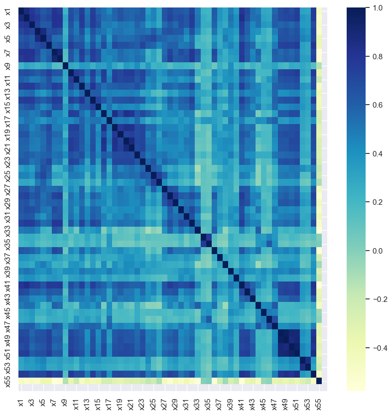

```python
df1 = df.query('data_quality == 1')
sns.heatmap(df1.corr(), cmap="YlGnBu")
sns.set(rc={'figure.figsize':(10,10)})
df1.corr()
```

|  | x1 | x2 | x3 | x4 | x5 | x6 | x7 | x8 | x9 | x10 | ... | x47 | x48 | x49 | x50 | x51 | x52 | x53 | x54 | x55 | data_quality |
| --- | --- | --- | --- | --- | --- | --- | --- | --- | --- | --- | --- | --- | --- | --- | --- | --- | --- | --- | --- | --- | --- |
| x1 | 1.000000 | 0.884298 | 0.803787 | 0.742480 | 0.681023 | 0.681274 | 0.831980 | 0.774739 | 0.217148 | 0.662659 | ... | 0.602691 | 0.612943 | 0.656019 | 0.567364 | 0.624375 | 0.190790 | 0.319660 | 0.791270 | -0.425537 | 0.169017 |
| x2 | 0.884298 | 1.000000 | 0.821081 | 0.786397 | 0.721359 | 0.719285 | 0.830045 | 0.794075 | 0.319210 | 0.682605 | ... | 0.655008 | 0.597023 | 0.633753 | 0.580847 | 0.620012 | 0.225702 | 0.362517 | 0.766472 | -0.436099 | 0.221218 |
| x3 | 0.803787 | 0.821081 | 1.000000 | 0.732661 | 0.655382 | 0.647977 | 0.814963 | 0.794599 | 0.279675 | 0.658752 | ... | 0.616425 | 0.504143 | 0.542878 | 0.475292 | 0.512872 | 0.243157 | 0.374851 | 0.693359 | -0.424607 | 0.158136 |
| x4 | 0.742480 | 0.786397 | 0.732661 | 1.000000 | 0.874429 | 0.706623 | 0.730976 | 0.695827 | 0.223771 | 0.628404 | ... | 0.521165 | 0.562735 | 0.599700 | 0.505693 | 0.557495 | 0.189833 | 0.299375 | 0.757422 | -0.455965 | 0.182606 |
| x5 | 0.681023 | 0.721359 | 0.655382 | 0.874429 | 1.000000 | 0.752397 | 0.625267 | 0.569402 | 0.287360 | 0.666702 | ... | 0.465721 | 0.573166 | 0.599736 | 0.528965 | 0.568933 | 0.188778 | 0.279951 | 0.740024 | -0.357362 | 0.198833 |
| x6 | 0.681274 | 0.719285 | 0.647977 | 0.706623 | 0.752397 | 1.000000 | 0.608958 | 0.624043 | 0.392366 | 0.748401 | ... | 0.522623 | 0.632008 | 0.650802 | 0.606197 | 0.629885 | 0.224378 | 0.331743 | 0.791338 | -0.344023 | 0.198752 |
| x7 | 0.831980 | 0.830045 | 0.814963 | 0.730976 | 0.625267 | 0.608958 | 1.000000 | 0.891627 | 0.206386 | 0.622880 | ... | 0.641407 | 0.494813 | 0.545046 | 0.470490 | 0.520372 | 0.207465 | 0.316292 | 0.721097 | -0.504106 | 0.123849 |
| x8 | 0.774739 | 0.794075 | 0.794599 | 0.695827 | 0.569402 | 0.624043 | 0.891627 | 1.000000 | 0.158329 | 0.625783 | ... | 0.596037 | 0.501167 | 0.544109 | 0.470165 | 0.521742 | 0.211301 | 0.336127 | 0.740894 | -0.482646 | 0.120322 |
| x9 | 0.217148 | 0.319210 | 0.279675 | 0.223771 | 0.287360 | 0.392366 | 0.206386 | 0.158329 | 1.000000 | 0.346015 | ... | 0.346810 | 0.197228 | 0.170221 | 0.249714 | 0.213846 | 0.223804 | 0.280977 | 0.173894 | -0.136714 | 0.132742 |
| x10 | 0.662659 | 0.682605 | 0.658752 | 0.628404 | 0.666702 | 0.748401 | 0.622880 | 0.625783 | 0.346015 | 1.000000 | ... | 0.506902 | 0.595554 | 0.629794 | 0.580353 | 0.617745 | 0.180595 | 0.279766 | 0.766962 | -0.309796 | 0.107034 |
| x11 | 0.573618 | 0.554878 | 0.477149 | 0.509792 | 0.548388 | 0.638304 | 0.505166 | 0.473158 | 0.276791 | 0.687120 | ... | 0.511451 | 0.570898 | 0.581399 | 0.565854 | 0.585236 | 0.149172 | 0.221830 | 0.664203 | -0.218521 | 0.086463 |
| x12 | 0.762381 | 0.784472 | 0.766096 | 0.689729 | 0.640390 | 0.682625 | 0.775395 | 0.730413 | 0.385335 | 0.710262 | ... | 0.608852 | 0.537792 | 0.568436 | 0.518654 | 0.550976 | 0.218299 | 0.337160 | 0.698716 | -0.407904 | 0.166682 |
| x13 | 0.478898 | 0.497514 | 0.527677 | 0.426593 | 0.398001 | 0.455652 | 0.532817 | 0.480319 | 0.369977 | 0.513177 | ... | 0.534175 | 0.340923 | 0.355134 | 0.348645 | 0.368203 | 0.291212 | 0.363541 | 0.469473 | -0.359099 | 0.102938 |
| x14 | 0.769205 | 0.777374 | 0.763960 | 0.693215 | 0.654762 | 0.682361 | 0.768434 | 0.739558 | 0.274226 | 0.729215 | ... | 0.604893 | 0.560579 | 0.596404 | 0.544909 | 0.584394 | 0.247421 | 0.347406 | 0.749809 | -0.398466 | 0.154950 |
| x15 | 0.594753 | 0.631717 | 0.654831 | 0.559940 | 0.471610 | 0.528155 | 0.656322 | 0.650757 | 0.360825 | 0.541765 | ... | 0.564782 | 0.394339 | 0.414897 | 0.398479 | 0.415792 | 0.201677 | 0.293466 | 0.581662 | -0.367592 | 0.128438 |
| x16 | 0.452583 | 0.456324 | 0.423442 | 0.434432 | 0.510484 | 0.601904 | 0.376979 | 0.391061 | 0.329695 | 0.652007 | ... | 0.323387 | 0.483985 | 0.470983 | 0.513996 | 0.502347 | 0.174762 | 0.238645 | 0.585940 | -0.199171 | 0.076034 |
| x17 | 0.430310 | 0.483858 | 0.459957 | 0.381054 | 0.371230 | 0.433975 | 0.459196 | 0.424475 | 0.403504 | 0.395498 | ... | 0.511937 | 0.320480 | 0.294858 | 0.336154 | 0.322620 | 0.151855 | 0.230039 | 0.386765 | -0.227309 | 0.073733 |
| x18 | 0.569747 | 0.561990 | 0.458903 | 0.507980 | 0.584307 | 0.671352 | 0.493156 | 0.471510 | 0.351736 | 0.674206 | ... | 0.465120 | 0.517688 | 0.514460 | 0.525497 | 0.527894 | 0.186115 | 0.264943 | 0.664012 | -0.287762 | 0.107238 |
| x19 | 0.640331 | 0.631052 | 0.521198 | 0.548635 | 0.555767 | 0.635585 | 0.570769 | 0.557275 | 0.262872 | 0.668965 | ... | 0.483017 | 0.544663 | 0.554019 | 0.536880 | 0.557911 | 0.164268 | 0.241803 | 0.694054 | -0.318152 | 0.086682 |
| x20 | 0.530515 | 0.524411 | 0.481091 | 0.455414 | 0.504423 | 0.593082 | 0.469820 | 0.482908 | 0.352795 | 0.678859 | ... | 0.387428 | 0.512988 | 0.499714 | 0.531084 | 0.527547 | 0.161873 | 0.245154 | 0.618130 | -0.251467 | 0.080140 |
| x21 | 0.548346 | 0.536228 | 0.489164 | 0.476090 | 0.537463 | 0.603401 | 0.489630 | 0.475617 | 0.335548 | 0.705699 | ... | 0.380183 | 0.522282 | 0.520483 | 0.536407 | 0.541113 | 0.154524 | 0.240284 | 0.637823 | -0.256654 | 0.064663 |
| x22 | 0.563074 | 0.614829 | 0.567284 | 0.553713 | 0.583126 | 0.600253 | 0.531906 | 0.558214 | 0.378515 | 0.637881 | ... | 0.507779 | 0.478979 | 0.478343 | 0.471902 | 0.484323 | 0.152008 | 0.252958 | 0.617587 | -0.274577 | 0.127548 |
| x23 | 0.624782 | 0.641055 | 0.548365 | 0.602609 | 0.667002 | 0.728095 | 0.512198 | 0.533270 | 0.274035 | 0.733700 | ... | 0.411036 | 0.582281 | 0.608858 | 0.554748 | 0.592759 | 0.168820 | 0.246695 | 0.718171 | -0.225560 | 0.121602 |
| x24 | 0.333226 | 0.406745 | 0.324643 | 0.474742 | 0.599433 | 0.600628 | 0.230449 | 0.230894 | 0.401606 | 0.559652 | ... | 0.259538 | 0.367027 | 0.374069 | 0.378204 | 0.379264 | 0.154124 | 0.206253 | 0.476305 | -0.173692 | 0.131939 |
| x25 | 0.470203 | 0.485970 | 0.407675 | 0.643161 | 0.716429 | 0.563169 | 0.364355 | 0.323716 | 0.228128 | 0.488205 | ... | 0.280284 | 0.422396 | 0.439371 | 0.386182 | 0.420766 | 0.116503 | 0.172435 | 0.569783 | -0.206862 | 0.157464 |
| x26 | 0.301773 | 0.325462 | 0.285593 | 0.477118 | 0.620912 | 0.427267 | 0.231550 | 0.172079 | 0.276906 | 0.342579 | ... | 0.215436 | 0.288984 | 0.276193 | 0.266359 | 0.274167 | 0.074677 | 0.101536 | 0.358795 | -0.117000 | 0.151591 |
| x27 | 0.681718 | 0.679280 | 0.586850 | 0.669564 | 0.650395 | 0.573207 | 0.625915 | 0.596896 | 0.246995 | 0.461376 | ... | 0.422959 | 0.477823 | 0.507841 | 0.430703 | 0.480092 | 0.147587 | 0.251539 | 0.659572 | -0.415501 | 0.143218 |
| x28 | 0.727217 | 0.742722 | 0.662261 | 0.695719 | 0.582506 | 0.615413 | 0.727714 | 0.758962 | 0.149993 | 0.548287 | ... | 0.486841 | 0.501415 | 0.549300 | 0.451855 | 0.511891 | 0.173909 | 0.283636 | 0.736262 | -0.498238 | 0.104956 |
| x29 | 0.638709 | 0.657346 | 0.566789 | 0.641837 | 0.573217 | 0.592207 | 0.592340 | 0.621676 | 0.208029 | 0.519723 | ... | 0.426007 | 0.542809 | 0.567045 | 0.490580 | 0.536562 | 0.194403 | 0.305525 | 0.689959 | -0.390323 | 0.153747 |
| x30 | 0.645714 | 0.697388 | 0.687077 | 0.665053 | 0.564353 | 0.499060 | 0.698299 | 0.652092 | 0.219616 | 0.525088 | ... | 0.526656 | 0.376912 | 0.404361 | 0.339186 | 0.371371 | 0.148038 | 0.238231 | 0.552747 | -0.457215 | 0.107744 |
| x31 | 0.632984 | 0.658494 | 0.635053 | 0.549869 | 0.467789 | 0.526542 | 0.660622 | 0.674602 | 0.203422 | 0.559713 | ... | 0.472870 | 0.432002 | 0.456556 | 0.419867 | 0.458335 | 0.184100 | 0.322199 | 0.624991 | -0.383026 | 0.138001 |
| x32 | 0.704158 | 0.738299 | 0.725387 | 0.686796 | 0.584837 | 0.575717 | 0.750172 | 0.748466 | 0.201836 | 0.604875 | ... | 0.527140 | 0.456875 | 0.495060 | 0.417005 | 0.470793 | 0.410956 | 0.440179 | 0.678156 | -0.448629 | 0.097870 |
| x33 | 0.531754 | 0.532963 | 0.556655 | 0.500751 | 0.319038 | 0.255764 | 0.657176 | 0.626005 | 0.043575 | 0.279358 | ... | 0.395747 | 0.201324 | 0.243920 | 0.160615 | 0.219401 | 0.125462 | 0.216845 | 0.368555 | -0.572245 | 0.094541 |
| x34 | 0.249639 | 0.288770 | 0.259996 | 0.249835 | 0.200464 | 0.240391 | 0.241080 | 0.204649 | 0.262616 | 0.171825 | ... | 0.383714 | 0.244377 | 0.228674 | 0.267903 | 0.253284 | 0.034043 | 0.085311 | 0.168143 | 0.010234 | 0.125469 |
| x35 | 0.224490 | 0.250637 | 0.272643 | 0.198592 | 0.166510 | 0.173515 | 0.218082 | 0.190481 | 0.183568 | 0.117686 | ... | 0.381853 | 0.159541 | 0.151535 | 0.175864 | 0.165923 | 0.078759 | 0.091673 | 0.105715 | 0.046510 | 0.120669 |
| x36 | 0.626943 | 0.604519 | 0.557581 | 0.505805 | 0.433243 | 0.468709 | 0.691301 | 0.615928 | 0.165049 | 0.395847 | ... | 0.489694 | 0.372119 | 0.397399 | 0.337248 | 0.376577 | 0.237427 | 0.293814 | 0.508078 | -0.453760 | 0.122703 |
| x37 | 0.338411 | 0.333759 | 0.318753 | 0.276835 | 0.250622 | 0.257478 | 0.332988 | 0.292442 | 0.193138 | 0.303609 | ... | 0.216066 | 0.259383 | 0.273144 | 0.256732 | 0.279541 | 0.102269 | 0.161669 | 0.313906 | -0.199691 | 0.099477 |
| x38 | 0.415638 | 0.419817 | 0.374690 | 0.363784 | 0.424625 | 0.450444 | 0.363127 | 0.323040 | 0.264930 | 0.437439 | ... | 0.277380 | 0.411464 | 0.391735 | 0.430886 | 0.391220 | 0.069880 | 0.162613 | 0.430139 | -0.084401 | 0.082718 |
| x39 | 0.458124 | 0.514256 | 0.479248 | 0.404982 | 0.415154 | 0.468746 | 0.390391 | 0.345423 | 0.422140 | 0.446362 | ... | 0.439782 | 0.392705 | 0.392330 | 0.410818 | 0.409231 | 0.210742 | 0.305203 | 0.436283 | -0.255834 | 0.084857 |
| x40 | 0.382904 | 0.444804 | 0.420341 | 0.380939 | 0.344602 | 0.395138 | 0.391548 | 0.370644 | 0.235771 | 0.377980 | ... | 0.392082 | 0.283338 | 0.292614 | 0.277556 | 0.277347 | 0.091564 | 0.145029 | 0.345967 | -0.193823 | 0.103232 |
| x41 | 0.808290 | 0.840744 | 0.774398 | 0.775053 | 0.710186 | 0.774496 | 0.779407 | 0.774332 | 0.296274 | 0.698997 | ... | 0.602441 | 0.610326 | 0.641064 | 0.566961 | 0.611978 | 0.227902 | 0.361599 | 0.834052 | -0.531626 | 0.195063 |
| x42 | 0.706068 | 0.661812 | 0.584446 | 0.596633 | 0.566803 | 0.633526 | 0.590610 | 0.592734 | 0.189474 | 0.590811 | ... | 0.406813 | 0.624193 | 0.662017 | 0.595881 | 0.629244 | 0.260954 | 0.365380 | 0.771285 | -0.318703 | 0.188908 |
| x43 | 0.538625 | 0.513306 | 0.424011 | 0.429948 | 0.447979 | 0.566378 | 0.435425 | 0.439496 | 0.276353 | 0.522991 | ... | 0.367896 | 0.490648 | 0.510521 | 0.488321 | 0.504980 | 0.222777 | 0.316208 | 0.606077 | -0.307613 | 0.153336 |
| x44 | 0.552443 | 0.601723 | 0.577608 | 0.457789 | 0.329669 | 0.357739 | 0.634480 | 0.577491 | 0.211822 | 0.275856 | ... | 0.670846 | 0.236522 | 0.257156 | 0.221998 | 0.243478 | 0.146307 | 0.221651 | 0.335143 | -0.391617 | 0.162425 |
| x45 | 0.317912 | 0.393988 | 0.371736 | 0.269772 | 0.304032 | 0.339493 | 0.316751 | 0.274411 | 0.305263 | 0.252929 | ... | 0.496403 | 0.261855 | 0.244143 | 0.301584 | 0.259448 | 0.124251 | 0.163356 | 0.229982 | -0.001015 | 0.130452 |
| x46 | 0.303722 | 0.350842 | 0.345930 | 0.213999 | 0.234068 | 0.297556 | 0.307556 | 0.253954 | 0.312942 | 0.235541 | ... | 0.656136 | 0.247847 | 0.235594 | 0.285282 | 0.257829 | 0.071830 | 0.097196 | 0.188391 | 0.024045 | 0.075177 |
| x47 | 0.602691 | 0.655008 | 0.616425 | 0.521165 | 0.465721 | 0.522623 | 0.641407 | 0.596037 | 0.346810 | 0.506902 | ... | 1.000000 | 0.374036 | 0.383708 | 0.388416 | 0.394877 | 0.165599 | 0.250308 | 0.507445 | -0.321969 | 0.151164 |
| x48 | 0.612943 | 0.597023 | 0.504143 | 0.562735 | 0.573166 | 0.632008 | 0.494813 | 0.501167 | 0.197228 | 0.595554 | ... | 0.374036 | 1.000000 | 0.971016 | 0.923165 | 0.927539 | 0.215355 | 0.319796 | 0.700660 | -0.233440 | 0.174712 |
| x49 | 0.656019 | 0.633753 | 0.542878 | 0.599700 | 0.599736 | 0.650802 | 0.545046 | 0.544109 | 0.170221 | 0.629794 | ... | 0.383708 | 0.971016 | 1.000000 | 0.893348 | 0.933288 | 0.211440 | 0.322133 | 0.748022 | -0.269622 | 0.154791 |
| x50 | 0.567364 | 0.580847 | 0.475292 | 0.505693 | 0.528965 | 0.606197 | 0.470490 | 0.470165 | 0.249714 | 0.580353 | ... | 0.388416 | 0.923165 | 0.893348 | 1.000000 | 0.957772 | 0.216738 | 0.325990 | 0.657311 | -0.185531 | 0.166556 |
| x51 | 0.624375 | 0.620012 | 0.512872 | 0.557495 | 0.568933 | 0.629885 | 0.520372 | 0.521742 | 0.213846 | 0.617745 | ... | 0.394877 | 0.927539 | 0.933288 | 0.957772 | 1.000000 | 0.212175 | 0.325548 | 0.714615 | -0.237245 | 0.148685 |
| x52 | 0.190790 | 0.225702 | 0.243157 | 0.189833 | 0.188778 | 0.224378 | 0.207465 | 0.211301 | 0.223804 | 0.180595 | ... | 0.165599 | 0.215355 | 0.211440 | 0.216738 | 0.212175 | 1.000000 | 0.847554 | 0.219114 | -0.115404 | 0.055803 |
| x53 | 0.319660 | 0.362517 | 0.374851 | 0.299375 | 0.279951 | 0.331743 | 0.316292 | 0.336127 | 0.280977 | 0.279766 | ... | 0.250308 | 0.319796 | 0.322133 | 0.325990 | 0.325548 | 0.847554 | 1.000000 | 0.339020 | -0.168633 | 0.098391 |
| x54 | 0.791270 | 0.766472 | 0.693359 | 0.757422 | 0.740024 | 0.791338 | 0.721097 | 0.740894 | 0.173894 | 0.766962 | ... | 0.507445 | 0.700660 | 0.748022 | 0.657311 | 0.714615 | 0.219114 | 0.339020 | 1.000000 | -0.430578 | 0.151222 |
| x55 | -0.425537 | -0.436099 | -0.424607 | -0.455965 | -0.357362 | -0.344023 | -0.504106 | -0.482646 | -0.136714 | -0.309796 | ... | -0.321969 | -0.233440 | -0.269622 | -0.185531 | -0.237245 | -0.115404 | -0.168633 | -0.430578 | 1.000000 | -0.026905 |
| data_quality | 0.169017 | 0.221218 | 0.158136 | 0.182606 | 0.198833 | 0.198752 | 0.123849 | 0.120322 | 0.132742 | 0.107034 | ... | 0.151164 | 0.174712 | 0.154791 | 0.166556 | 0.148685 | 0.055803 | 0.098391 | 0.151222 | -0.026905 | 1.000000 |

56 rows × 56 columns

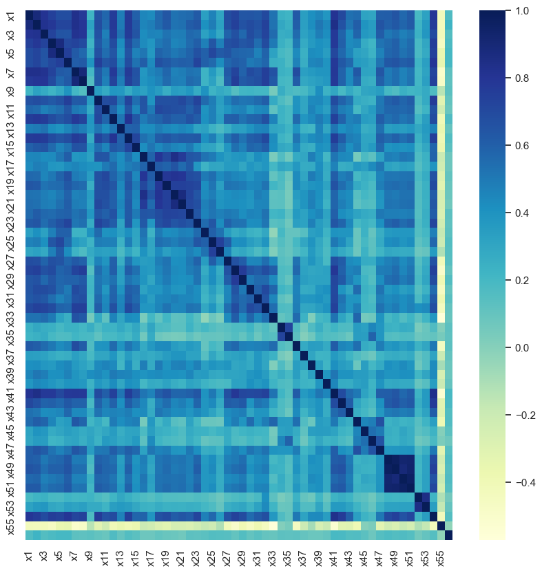

```python
clean_df = df.copy().dropna()
sns.heatmap(clean_df.corr(), cmap="YlGnBu")
sns.set(rc={'figure.figsize':(10,10)})
clean_df.corr()
```

Our goal in this tutorial is to examine and understand the difference between the Cost of Living of different countires. Since the CoL of each country is indendent of one another, to deal with the missing data we will choose to remove the rows with NaN values. However me must take into consideration that this will reduce the size of our data, which we need to take into account when doing our anlysis.

To gain the largest set of data we will be using the newly made clean_df. Using the shape variable we can learn how many observations are contained in this dataset.

```python
clean_df.shape
```

```
(1278, 58)
```

Now we will begin modifying the data set for our purposes.

First lets remove the "data_quality" collumn since it is no longer needed.

```python
# Droping data_quality collumn
clean_df.drop(columns=['data_quality'], inplace=True)
clean_df
```

|  | city | country | x1 | x2 | x3 | x4 | x5 | x6 | x7 | x8 | ... | x46 | x47 | x48 | x49 | x50 | x51 | x52 | x53 | x54 | x55 |
| --- | --- | --- | --- | --- | --- | --- | --- | --- | --- | --- | --- | --- | --- | --- | --- | --- | --- | --- | --- | --- | --- |
| 0 | Seoul | South Korea | 7.68 | 53.78 | 6.15 | 3.07 | 4.99 | 3.93 | 1.48 | 0.79 | ... | 70.81 | 110.36 | 742.54 | 557.52 | 2669.12 | 1731.08 | 22067.70 | 10971.90 | 2689.62 | 3.47 |
| 1 | Shanghai | China | 5.69 | 39.86 | 5.69 | 1.14 | 4.27 | 3.98 | 0.53 | 0.33 | ... | 88.21 | 123.51 | 1091.93 | 569.88 | 2952.70 | 1561.59 | 17746.11 | 9416.35 | 1419.87 | 5.03 |
| 2 | Guangzhou | China | 4.13 | 28.47 | 4.98 | 0.85 | 1.71 | 3.54 | 0.44 | 0.33 | ... | 66.73 | 43.89 | 533.28 | 317.45 | 1242.24 | 688.05 | 12892.82 | 5427.45 | 1211.68 | 5.19 |
| 3 | Mumbai | India | 3.68 | 18.42 | 3.68 | 2.46 | 4.30 | 2.48 | 0.48 | 0.19 | ... | 49.87 | 41.17 | 522.40 | 294.05 | 1411.12 | 699.80 | 6092.45 | 2777.51 | 640.81 | 7.96 |
| 4 | Delhi | India | 4.91 | 22.11 | 4.30 | 1.84 | 3.68 | 1.77 | 0.49 | 0.19 | ... | 49.99 | 36.50 | 229.84 | 135.31 | 601.02 | 329.15 | 2506.73 | 1036.74 | 586.46 | 8.06 |
| ... | ... | ... | ... | ... | ... | ... | ... | ... | ... | ... | ... | ... | ... | ... | ... | ... | ... | ... | ... | ... | ... |
| 4809 | Gig Harbor | United States | 12.00 | 40.00 | 10.50 | 7.00 | 6.00 | 5.21 | 2.48 | 1.94 | ... | 87.17 | 101.67 | 1800.00 | 2000.00 | 3000.00 | 2400.00 | 3821.19 | 2852.44 | 4500.00 | 5.23 |
| 4826 | Lysa nad Labem | Czech Republic | 4.33 | 32.40 | 5.19 | 1.25 | 2.29 | 2.15 | 1.24 | 0.97 | ... | 98.74 | 73.50 | 605.62 | 410.96 | 854.36 | 583.99 | 3028.10 | 1297.76 | 634.46 | 7.00 |
| 4928 | Murovani Kurylivtsi | Ukraine | 2.72 | 12.24 | 2.69 | 0.68 | 1.09 | 0.68 | 0.24 | 0.14 | ... | 59.56 | 61.19 | 108.79 | 95.19 | 163.18 | 122.38 | 237.97 | 231.17 | 365.79 | 13.05 |
| 4945 | Tirupati | India | 2.46 | 9.21 | 4.30 | 2.21 | 3.07 | 1.47 | 0.46 | 0.14 | ... | 38.89 | 37.25 | 82.90 | 61.41 | 184.23 | 128.96 | 661.00 | 396.60 | 614.09 | 7.97 |
| 4950 | Egilsstadhir | Iceland | 17.01 | 70.87 | 8.50 | 4.25 | 3.54 | 3.90 | 1.77 | 1.42 | ... | 141.74 | 146.00 | 637.85 | 531.54 | 1700.92 | 1417.43 | 2019.84 | 1771.79 | 2480.51 | 5.00 |

1278 rows × 57 columns

We want to create a new collumn named "Sum CoL". This parameter will be the sum of the cost of living parameters and will repersent the overall expected cost of living for each city.

We also want to create a collumn named "sum_rent". This parameter will be the sum of the cost of rent and will reperesented the aggregated cost of rent for each city.

```python
# Summing all costs excluding rent cost collumns
clean_df["sum_CoL"] = clean_df.iloc[:,2:48].sum(axis=1)
# Summing all rent cost collumns
clean_df["sum_rent"] = clean_df.iloc[:,49:54].sum(axis=1)
clean_df
```

|  | city | country | x1 | x2 | x3 | x4 | x5 | x6 | x7 | x8 | ... | x48 | x49 | x50 | x51 | x52 | x53 | x54 | x55 | sum_CoL | sum_rent |
| --- | --- | --- | --- | --- | --- | --- | --- | --- | --- | --- | --- | --- | --- | --- | --- | --- | --- | --- | --- | --- | --- |
| 0 | Seoul | South Korea | 7.68 | 53.78 | 6.15 | 3.07 | 4.99 | 3.93 | 1.48 | 0.79 | ... | 742.54 | 557.52 | 2669.12 | 1731.08 | 22067.70 | 10971.90 | 2689.62 | 3.47 | 76076.50 | 27767.96 |
| 1 | Shanghai | China | 5.69 | 39.86 | 5.69 | 1.14 | 4.27 | 3.98 | 0.53 | 0.33 | ... | 1091.93 | 569.88 | 2952.70 | 1561.59 | 17746.11 | 9416.35 | 1419.87 | 5.03 | 68986.00 | 23922.21 |
| 2 | Guangzhou | China | 4.13 | 28.47 | 4.98 | 0.85 | 1.71 | 3.54 | 0.44 | 0.33 | ... | 533.28 | 317.45 | 1242.24 | 688.05 | 12892.82 | 5427.45 | 1211.68 | 5.19 | 68289.57 | 15673.84 |
| 3 | Mumbai | India | 3.68 | 18.42 | 3.68 | 2.46 | 4.30 | 2.48 | 0.48 | 0.19 | ... | 522.40 | 294.05 | 1411.12 | 699.80 | 6092.45 | 2777.51 | 640.81 | 7.96 | 39155.52 | 9019.82 |
| 4 | Delhi | India | 4.91 | 22.11 | 4.30 | 1.84 | 3.68 | 1.77 | 0.49 | 0.19 | ... | 229.84 | 135.31 | 601.02 | 329.15 | 2506.73 | 1036.74 | 586.46 | 8.06 | 37572.85 | 3802.05 |
| ... | ... | ... | ... | ... | ... | ... | ... | ... | ... | ... | ... | ... | ... | ... | ... | ... | ... | ... | ... | ... | ... |
| 4809 | Gig Harbor | United States | 12.00 | 40.00 | 10.50 | 7.00 | 6.00 | 5.21 | 2.48 | 1.94 | ... | 1800.00 | 2000.00 | 3000.00 | 2400.00 | 3821.19 | 2852.44 | 4500.00 | 5.23 | 71029.09 | 13021.19 |
| 4826 | Lysa nad Labem | Czech Republic | 4.33 | 32.40 | 5.19 | 1.25 | 2.29 | 2.15 | 1.24 | 0.97 | ... | 605.62 | 410.96 | 854.36 | 583.99 | 3028.10 | 1297.76 | 634.46 | 7.00 | 70633.72 | 5483.03 |
| 4928 | Murovani Kurylivtsi | Ukraine | 2.72 | 12.24 | 2.69 | 0.68 | 1.09 | 0.68 | 0.24 | 0.14 | ... | 108.79 | 95.19 | 163.18 | 122.38 | 237.97 | 231.17 | 365.79 | 13.05 | 34052.18 | 727.51 |
| 4945 | Tirupati | India | 2.46 | 9.21 | 4.30 | 2.21 | 3.07 | 1.47 | 0.46 | 0.14 | ... | 82.90 | 61.41 | 184.23 | 128.96 | 661.00 | 396.60 | 614.09 | 7.97 | 28520.51 | 1118.50 |
| 4950 | Egilsstadhir | Iceland | 17.01 | 70.87 | 8.50 | 4.25 | 3.54 | 3.90 | 1.77 | 1.42 | ... | 637.85 | 531.54 | 1700.92 | 1417.43 | 2019.84 | 1771.79 | 2480.51 | 5.00 | 52840.75 | 6307.58 |

1278 rows × 59 columns

Next we will define a new df that will contain four new parameters. These parameters will be indexes that denote the parameter based on some base line to compare the cities with to each other.

Cost of Living Index - a relative parameter that that denotes the Cost of Living based on some base line

Rent Index - a relative parameter that that denotes the Rent based on some base line

Mortgage Rate Index - a relative parameter that that denotes the Mortgage Rate based on some base line

Salary Index - a relative parameter that that denotes the Salary based on some base line

First we need to select a country to act as the base line for our indicators For this tutorial we will be using the country with the sum_CoL value that is closest to the median sum_CoL

```python
clean_df["sum_CoL"].median()
```

```
56596.76
```

We see that the median is 56596.76, then we will use the country that has the value closest to this for our base line.

```python
display(clean_df.loc[clean_df['sum_CoL'] > 56496.76].loc[clean_df['sum_CoL'] < 56696.76])
clean_df.loc[clean_df['sum_CoL'] == 56590.30]
```

|  | city | country | x1 | x2 | x3 | x4 | x5 | x6 | x7 | x8 | ... | x48 | x49 | x50 | x51 | x52 | x53 | x54 | x55 | sum_CoL | sum_rent |
| --- | --- | --- | --- | --- | --- | --- | --- | --- | --- | --- | --- | --- | --- | --- | --- | --- | --- | --- | --- | --- | --- |
| 67 | Xi'an | China | 2.85 | 17.08 | 4.98 | 0.71 | 2.56 | 3.42 | 0.42 | 0.28 | ... | 284.71 | 185.06 | 664.32 | 422.32 | 2633.56 | 2277.68 | 1001.23 | 4.91 | 56545.57 | 4189.97 |
| 234 | Perth | Australia | 16.99 | 67.96 | 9.48 | 6.80 | 6.80 | 3.36 | 2.50 | 2.17 | ... | 1229.79 | 975.62 | 2043.14 | 1480.77 | 4587.16 | 3584.60 | 4255.91 | 3.92 | 56510.73 | 10316.48 |
| 480 | Tallinn | Estonia | 13.70 | 63.22 | 7.38 | 5.27 | 5.27 | 3.47 | 2.10 | 1.74 | ... | 700.34 | 507.55 | 1296.11 | 862.75 | 4241.03 | 2799.79 | 1423.70 | 2.28 | 56556.06 | 7607.78 |
| 488 | Halifax | Canada | 14.82 | 66.70 | 8.89 | 5.19 | 5.19 | 3.53 | 1.78 | 1.70 | ... | 1217.45 | 973.06 | 1919.75 | 1504.86 | 3764.62 | 2099.92 | 3072.15 | 4.63 | 56572.50 | 9379.74 |
| 902 | Duisburg | Germany | 10.54 | 47.42 | 9.48 | 4.06 | 4.21 | 3.06 | 2.85 | 2.56 | ... | 435.55 | 463.65 | 913.25 | 562.00 | 3161.24 | 2634.36 | 2123.30 | 1.38 | 56523.56 | 5535.69 |
| 964 | Madison | United States | 14.00 | 75.00 | 9.00 | 5.00 | 6.00 | 4.25 | 1.93 | 1.19 | ... | 1398.75 | 1083.50 | 2440.00 | 1879.17 | 4126.17 | 2152.78 | 3535.50 | 5.19 | 56590.30 | 10927.59 |
| 1070 | Christchurch | New Zealand | 14.11 | 64.14 | 8.34 | 5.77 | 6.41 | 3.46 | 2.23 | 1.96 | ... | 1002.99 | 934.84 | 1594.34 | 1395.04 | 3329.93 | 2142.28 | 3327.32 | 3.79 | 56645.86 | 8257.14 |
| 1161 | Alicante | Spain | 13.65 | 47.42 | 8.43 | 3.16 | 3.16 | 1.86 | 1.48 | 0.73 | ... | 686.11 | 579.56 | 1044.96 | 854.50 | 2072.37 | 1735.64 | 1493.77 | 1.95 | 56634.77 | 5237.50 |
| 1816 | Nijmegen | Netherlands | 15.81 | 73.76 | 8.43 | 5.80 | 5.27 | 3.24 | 3.08 | 2.70 | ... | 1106.43 | 843.00 | 1804.54 | 1580.62 | 4803.32 | 3635.42 | 2985.61 | 3.00 | 56603.22 | 10137.91 |
| 1817 | Saarbrucken | Germany | 10.54 | 77.98 | 10.01 | 3.69 | 4.21 | 3.51 | 2.59 | 2.26 | ... | 671.76 | 500.53 | 1327.72 | 869.34 | 1896.74 | 1580.62 | 2686.79 | 2.47 | 56556.30 | 5266.09 |

10 rows × 59 columns

|  | city | country | x1 | x2 | x3 | x4 | x5 | x6 | x7 | x8 | ... | x48 | x49 | x50 | x51 | x52 | x53 | x54 | x55 | sum_CoL | sum_rent |
| --- | --- | --- | --- | --- | --- | --- | --- | --- | --- | --- | --- | --- | --- | --- | --- | --- | --- | --- | --- | --- | --- |
| 964 | Madison | United States | 14.0 | 75.0 | 9.0 | 5.0 | 6.0 | 4.25 | 1.93 | 1.19 | ... | 1398.75 | 1083.5 | 2440.0 | 1879.17 | 4126.17 | 2152.78 | 3535.5 | 5.19 | 56590.3 | 10927.59 |

1 rows × 59 columns

We see that Madison, US has the closest sum_CoL to the median, so that will serve as our base line for our indexes

```python
# Creating the index_df to store the parameter indicies
med_arr = clean_df.loc[clean_df['sum_CoL'] == 56590.30].to_numpy()
index_df = clean_df[['city','country']].copy()
index_df['salary_index'] = (clean_df['x54'] / med_arr[0][55]) * 100
index_df['mortgage_index'] = (clean_df['x55'] / med_arr[0][56]) * 100
index_df['CoL_index'] = (clean_df['sum_CoL'] / med_arr[0][57]) * 100
index_df['rent_index'] = (clean_df['sum_rent'] / med_arr[0][58]) * 100
index_df
```

|  | city | country | salary_index | mortgage_index | CoL_index | rent_index |
| --- | --- | --- | --- | --- | --- | --- |
| 0 | Seoul | South Korea | 76.074671 | 66.859345 | 134.433816 | 254.108728 |
| 1 | Shanghai | China | 40.160373 | 96.917148 | 121.904284 | 218.915699 |
| 2 | Guangzhou | China | 34.271814 | 100.000000 | 120.673631 | 143.433639 |
| 3 | Mumbai | India | 18.125018 | 153.371869 | 69.191222 | 82.541713 |
| 4 | Delhi | India | 16.587753 | 155.298651 | 66.394506 | 34.793125 |
| ... | ... | ... | ... | ... | ... | ... |
| 4809 | Gig Harbor | United States | 127.280441 | 100.770713 | 125.514602 | 119.158845 |
| 4826 | Lysa nad Labem | Czech Republic | 17.945411 | 134.874759 | 124.815949 | 50.176022 |
| 4928 | Murovani Kurylivtsi | Ukraine | 10.346203 | 251.445087 | 60.173175 | 6.657552 |
| 4945 | Tirupati | India | 17.369255 | 153.564547 | 50.398231 | 10.235560 |
| 4950 | Egilsstadhir | Iceland | 70.160091 | 96.339114 | 93.374218 | 57.721602 |

1278 rows × 6 columns

```python
index_df.describe()
```

|  | salary_index | mortgage_index | CoL_index | rent_index |
| --- | --- | --- | --- | --- |
| count | 1278.000000 | 1278.000000 | 1278.000000 | 1278.000000 |
| mean | 48.711477 | 126.289874 | 102.795903 | 64.460905 |
| std | 43.232961 | 107.393813 | 33.782076 | 80.503757 |
| min | 1.011172 | 15.414258 | 17.518108 | 3.314638 |
| 25% | 14.101117 | 53.275530 | 80.576176 | 26.009120 |
| 50% | 31.810211 | 98.554913 | 100.011415 | 48.517834 |
| 75% | 76.386933 | 168.593449 | 119.216867 | 84.607356 |
| max | 224.448593 | 1083.815029 | 453.750890 | 2223.411200 |

The above displays to us the statistical details of the indicies What these indicies show us is the percentage of each parameter. For example if a city has a Cost of Living Index of 150. Then the cost of living there is 50% more expensive than in Madison, US.

Now that we have prepared our data, we can begin the explorative analysis.

## 4. Exploration and Data Analysis

### Distribution Analysis

The first thing we want to do is visualize the distributions of our data.

We can create a box plot for each index and view their Central Tendency (mean, mode and median), Dispersion (range, variance), Quartiles (interquartile range), and Standard deviation.

This can be done using matplotlib's ploting functionality.

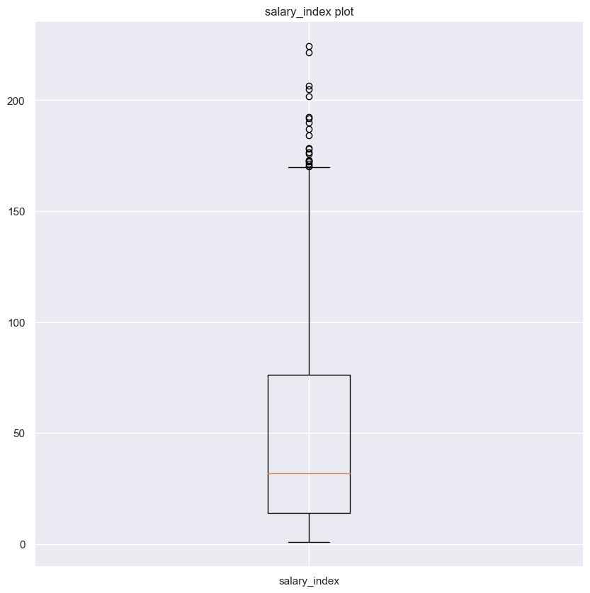

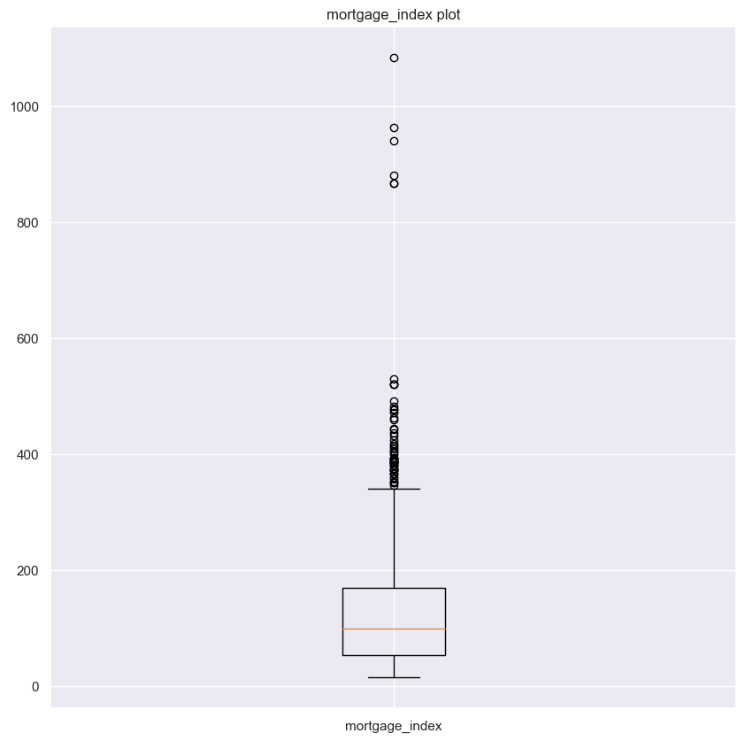

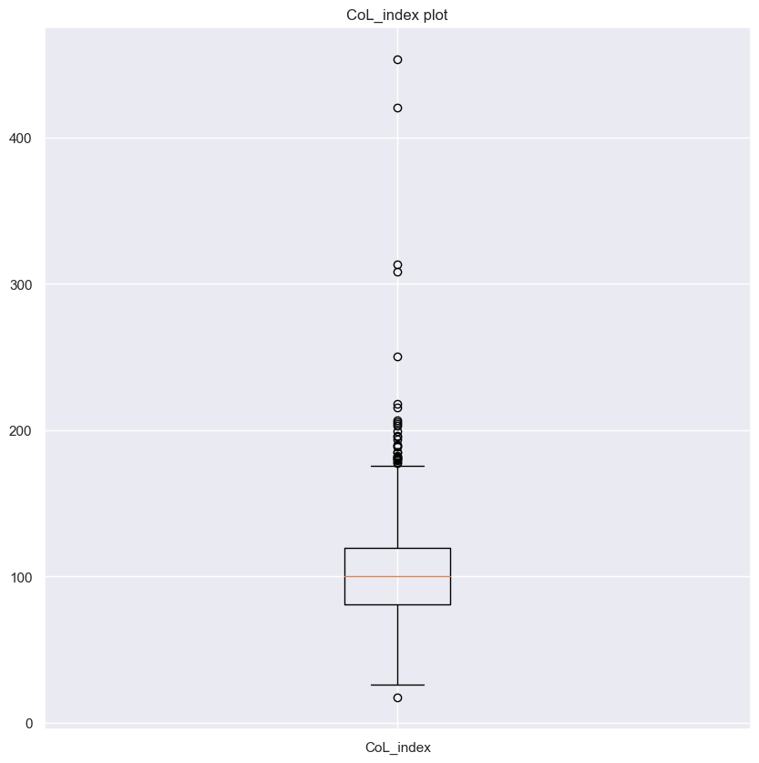

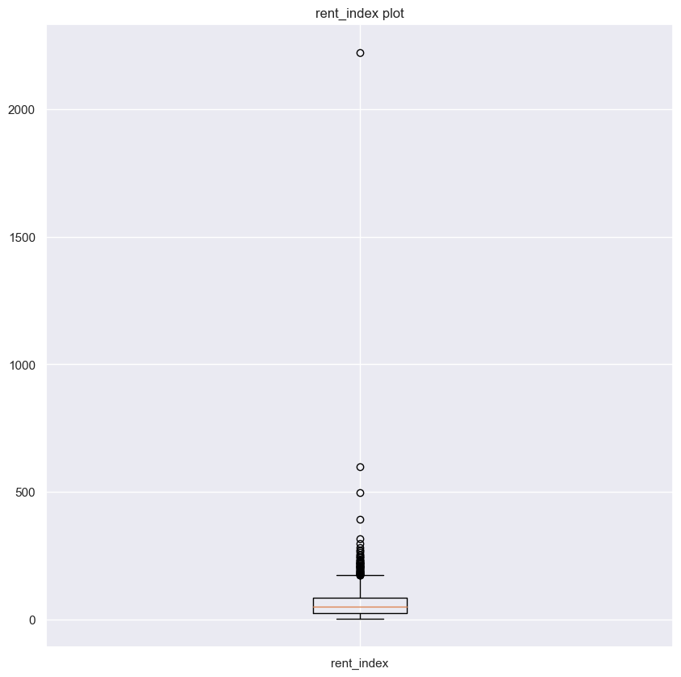

```python
# Creating Box Plots for each index
fig1, ax1 = plt.subplots()
ax1.set_title('salary_index plot')
ax1.boxplot([index_df['salary_index']], labels=['salary_index'])
plt.show()

fig1, ax1 = plt.subplots()
ax1.set_title('mortgage_index plot')
ax1.boxplot([index_df['mortgage_index']], labels=['mortgage_index'])
plt.show()

fig1, ax1 = plt.subplots()
ax1.set_title('CoL_index plot')
ax1.boxplot([index_df['CoL_index']], labels=['CoL_index'])
plt.show()

fig1, ax1 = plt.subplots()
ax1.set_title('rent_index plot')
ax1.boxplot([index_df['rent_index']], labels=['rent_index'])
plt.show()
```

From the Box Plots we can see that for most of the indicies, the data is mostly grouped together with far stretching outliers. The rent index for example has a particularly narrow distribution and short whiskers however far away outliers. While the salary index has a wider distribution and a longer whisker.

We can use a histogram and scatter plot to view this distribution better.

```
array([[<Axes: title={'center': 'rent_index'}>]], dtype=object)
```

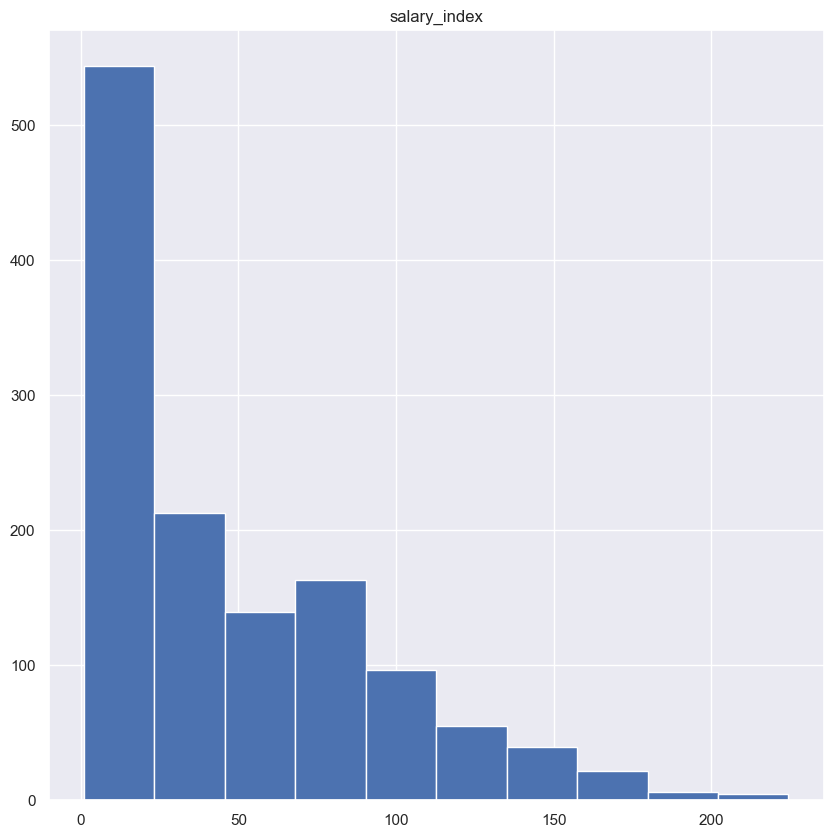

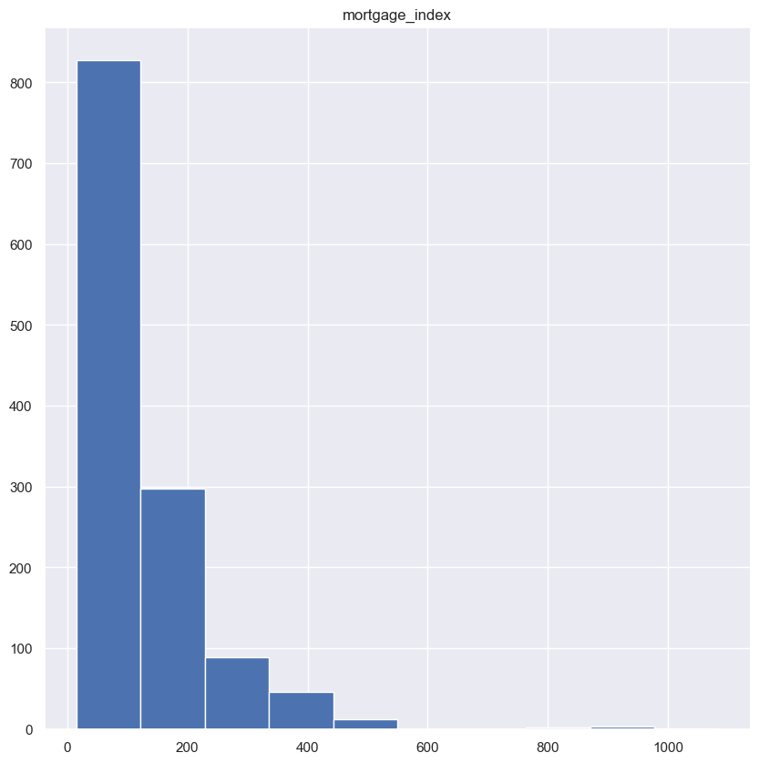

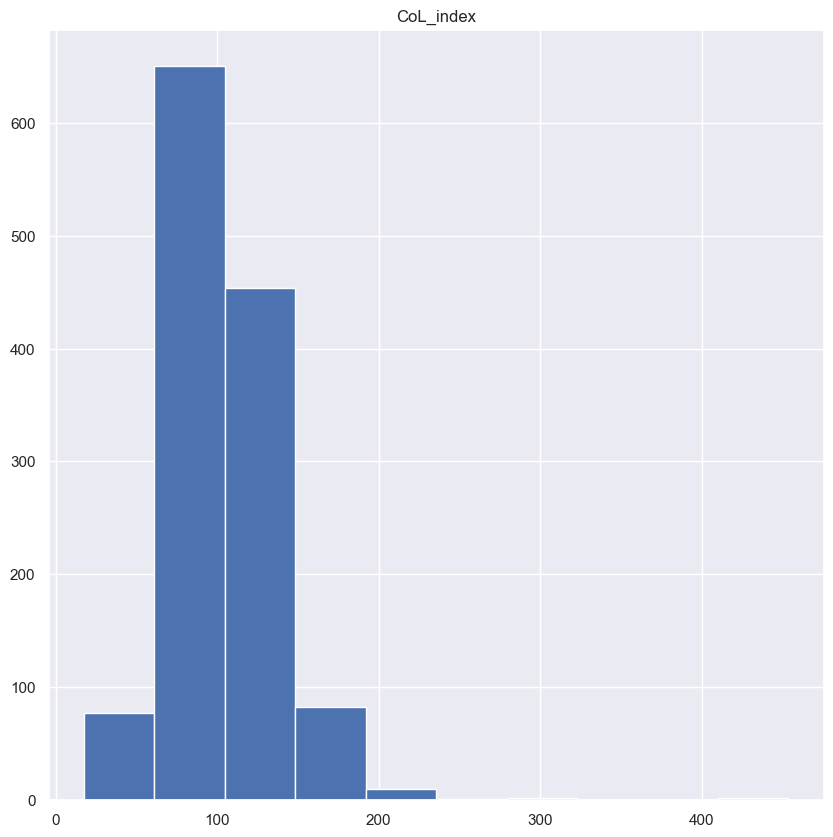

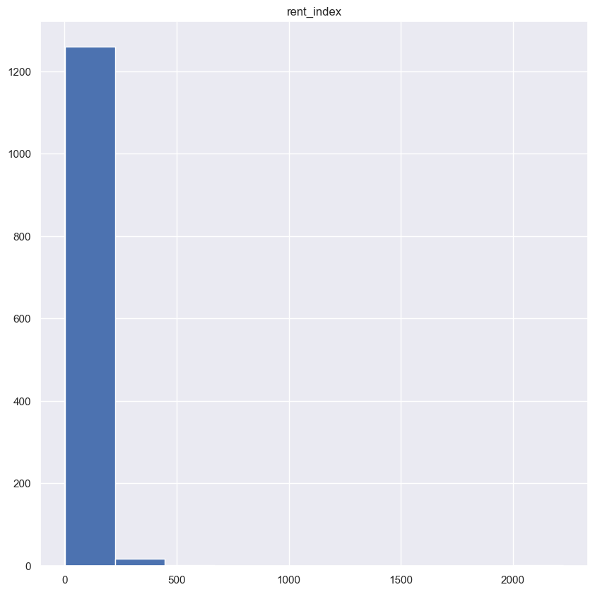

```python
# Creating Histograms for each index
index_df.hist(column='salary_index')
index_df.hist(column='mortgage_index')
index_df.hist(column='CoL_index')
index_df.hist(column='rent_index')
```

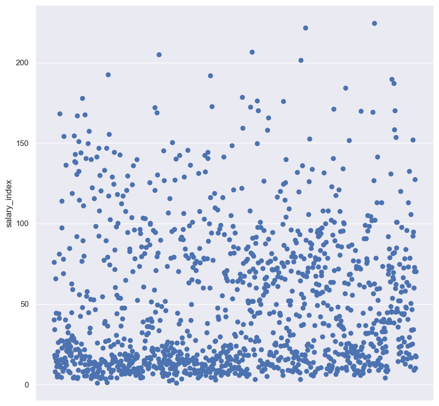

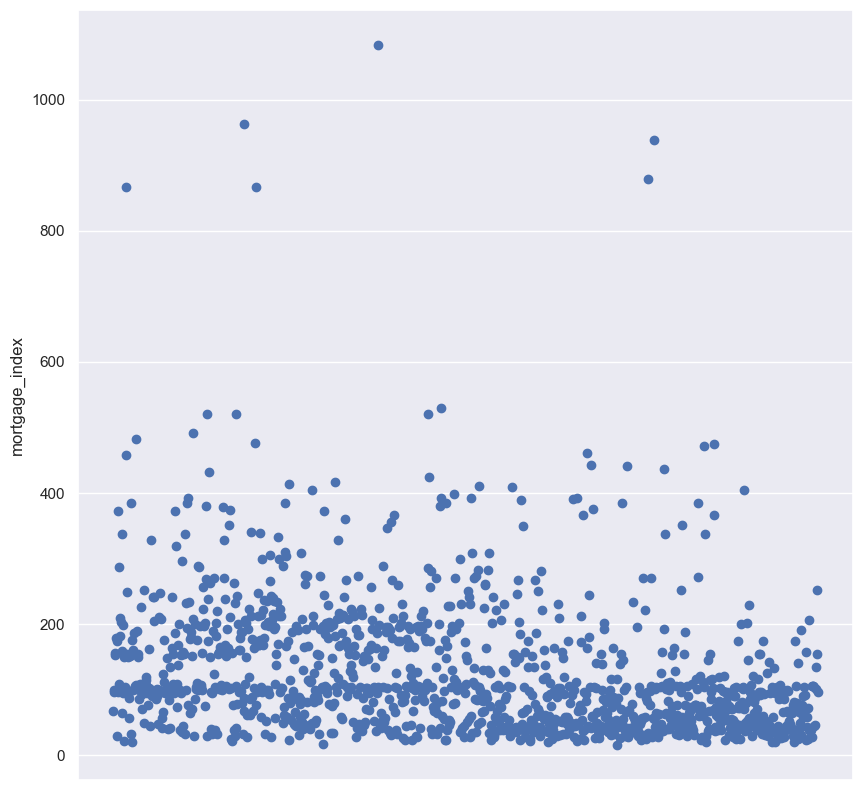

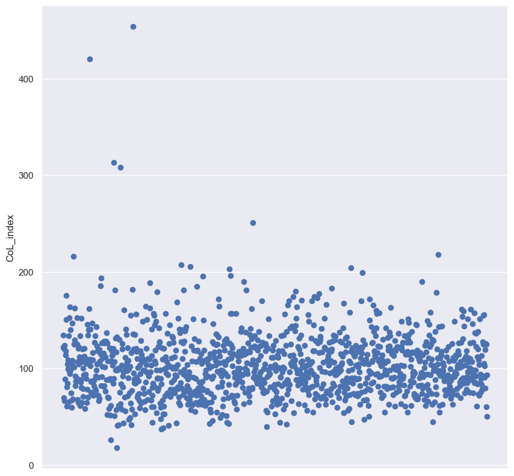

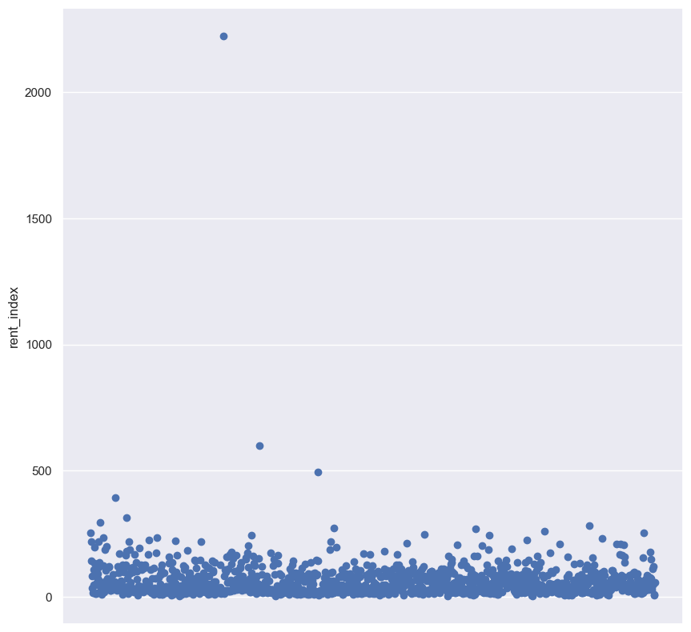

```python
# Creating Scatter Plots for each index
fig, ax = plt.subplots()
ax.scatter(index_df['city'], index_df['salary_index'])
plt.ylabel("salary_index")
ax = plt.gca()
ax.get_xaxis().set_visible(False)
plt.show()

fig, ax = plt.subplots()
ax.scatter(index_df['city'], index_df['mortgage_index'])
plt.ylabel("mortgage_index")
ax = plt.gca()
ax.get_xaxis().set_visible(False)
plt.show()

fig, ax = plt.subplots()
ax.scatter(index_df['city'], index_df['CoL_index'])
plt.ylabel("CoL_index")
ax = plt.gca()
ax.get_xaxis().set_visible(False)
plt.show()

fig, ax = plt.subplots()
ax.scatter(index_df['city'], index_df['rent_index'])
plt.ylabel("rent_index")
ax = plt.gca()
ax.get_xaxis().set_visible(False)
plt.show()
```

As with above, with can see the histograms and scatter plots follow the same trend as displayed in the box plots. This tells us that most cities share similar cost of living parameters and salary with a few being much higher than the rest.

### Correlation Analysis

Next we can examaine how the features correlate and interact with each other to determine if they have a relationship.

First will will examine the heatmap of the data.

|  | salary_index | mortgage_index | CoL_index | rent_index |
| --- | --- | --- | --- | --- |
| salary_index | 1.000000 | -0.430578 | 0.388807 | 0.452175 |
| mortgage_index | -0.430578 | 1.000000 | -0.106549 | -0.183087 |
| CoL_index | 0.388807 | -0.106549 | 1.000000 | 0.281246 |
| rent_index | 0.452175 | -0.183087 | 0.281246 | 1.000000 |

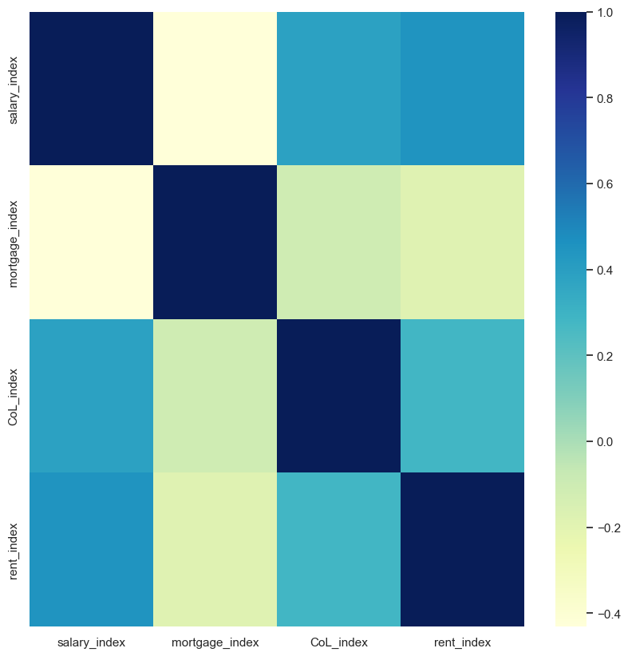

```python
# Creating HeatMap of the data
sns.heatmap(index_df.corr(), cmap="YlGnBu")
sns.set(rc={'figure.figsize':(10,10)})
# Showing correlation values
index_df.corr()
```

From the above we can see that salary_index has a positive correlation to Col_index and rent_index. However to gain a better understanding of their correlation we can create a pairwise plot of the data using seaborn's pairwise plot feature.

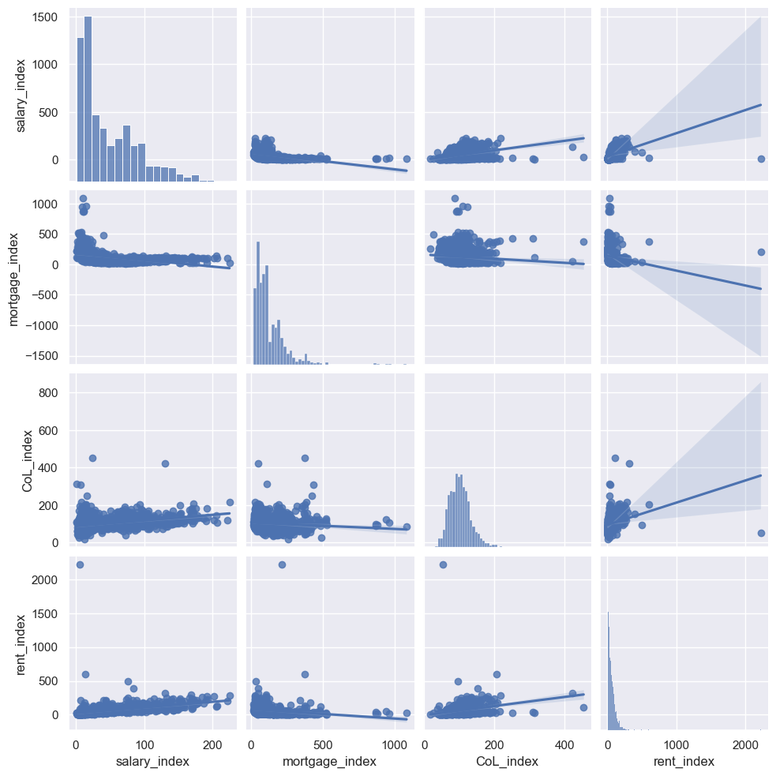

```python
# Creating pairwise plot of the data
sns.pairplot(index_df.iloc[:, 2:6], kind="reg")
```

We can see that our previous assumtion was correct and that there appears to be a linear relationship between salary_index and Col_index, rent_index. We can also see that salary_index has a negative linear relationship to mortgage_index.

To get a better view of the relationship between salary_index and Col_index, we can create a line plot with the data.

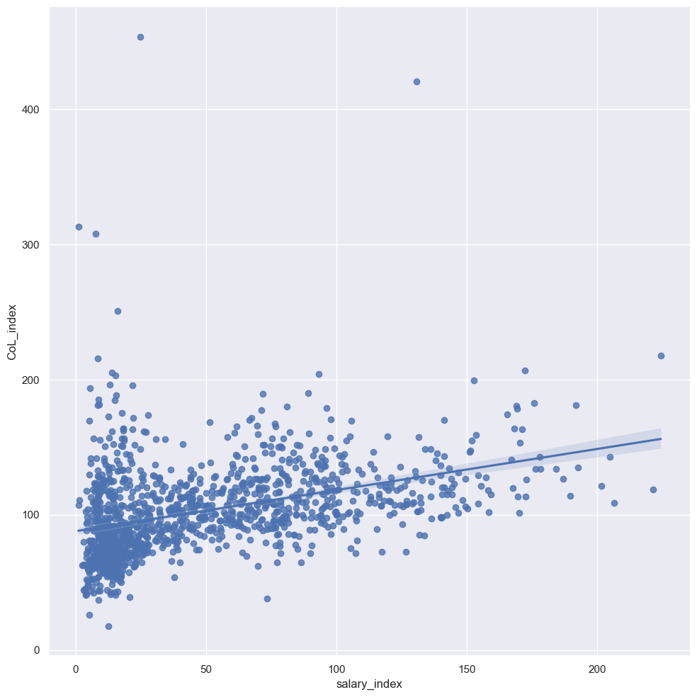

```python
# Creating Line Plot of CoL_index vs salary_index
sns.lmplot(x="salary_index",y="CoL_index",data=index_df,fit_reg=True, height=10)
```

From our analysis above we can expect Cost of Living to increase, Rent to increase, and Mortgage to decrease as Salary increases.

Now that we have an understanding of the correlation between our values we can test our hypothesis.

## 5. Hypothesis Testing

Hypothesis: There exist a correlation between the salary of a city and the Cost of Living, Rent, and Mortgage.

Testing H0:β1=0, Ha:β1≠0

To test our hypotheses we will first conduct the Model Utility Test to test if there exist a correlation between our parameters. To do this we will be using statsmodel's OLS Regression.

```python
# Creating OLS Regression for Col_index vs salary_index
res = smf.ols(formula='CoL_index ~ salary_index', data=index_df).fit()
res.summary()
```

OLS Regression Results

| Dep. Variable: | CoL_index | R-squared: | 0.151 |
| --- | --- | --- | --- |
| Model: | OLS | Adj. R-squared: | 0.151 |
| Method: | Least Squares | F-statistic: | 227.2 |
| Date: | Mon, 03 Feb 2025 | Prob (F-statistic): | 2.21e-47 |
| Time: | 18:42:09 | Log-Likelihood: | -6206.6 |
| No. Observations: | 1278 | AIC: | 1.242e+04 |
| Df Residuals: | 1276 | BIC: | 1.243e+04 |
| Df Model: | 1 |  |  |
| Covariance Type: | nonrobust |  |  |

|  | coef | std err | t | P>\|t\| | [0.025 | 0.975] |
| --- | --- | --- | --- | --- | --- | --- |
| Intercept | 87.9967 | 1.312 | 67.051 | 0.000 | 85.422 | 90.571 |
| salary_index | 0.3038 | 0.020 | 15.075 | 0.000 | 0.264 | 0.343 |

| Omnibus: | 950.095 | Durbin-Watson: | 1.973 |
| --- | --- | --- | --- |
| Prob(Omnibus): | 0.000 | Jarque-Bera (JB): | 32313.335 |
| Skew: | 3.058 | Prob(JB): | 0.00 |
| Kurtosis: | 26.862 | Cond. No. | 98.1 |

Notes:  
[1] Standard Errors assume that the covariance matrix of the errors is correctly specified.

At significance level **α=0.01** , we can reject our null hypothesis because our p value = 0. Thus we can claim that we have statistically significant evidence that there exist a linear relationship between the salary index and the Cost of Living Index.

```python
# Creating OLS Regression for rent_index vs salary_index
res = smf.ols(formula='rent_index ~ salary_index', data=index_df).fit()
res.summary()
```

OLS Regression Results

| Dep. Variable: | rent_index | R-squared: | 0.204 |
| --- | --- | --- | --- |
| Model: | OLS | Adj. R-squared: | 0.204 |
| Method: | Least Squares | F-statistic: | 327.9 |
| Date: | Mon, 03 Feb 2025 | Prob (F-statistic): | 2.06e-65 |
| Time: | 18:42:09 | Log-Likelihood: | -7275.0 |
| No. Observations: | 1278 | AIC: | 1.455e+04 |
| Df Residuals: | 1276 | BIC: | 1.456e+04 |
| Df Model: | 1 |  |  |
| Covariance Type: | nonrobust |  |  |

|  | coef | std err | t | P>\|t\| | [0.025 | 0.975] |
| --- | --- | --- | --- | --- | --- | --- |
| Intercept | 23.4463 | 3.028 | 7.744 | 0.000 | 17.506 | 29.386 |
| salary_index | 0.8420 | 0.046 | 18.109 | 0.000 | 0.751 | 0.933 |

| Omnibus: | 3062.879 | Durbin-Watson: | 1.967 |
| --- | --- | --- | --- |
| Prob(Omnibus): | 0.000 | Jarque-Bera (JB): | 25144895.141 |
| Skew: | 23.078 | Prob(JB): | 0.00 |
| Kurtosis: | 688.620 | Cond. No. | 98.1 |

Notes:  
[1] Standard Errors assume that the covariance matrix of the errors is correctly specified.

At significance level **α=0.01** , we can reject our null hypothesis because our p value = 0. Thus we can claim that we have statistically significant evidence that there exist a linear relationship between the salary index and the Rent Index.

```python
# Creating OLS Regression for mortgage_index vs salary_index
res = smf.ols(formula='mortgage_index ~ salary_index', data=index_df).fit()
res.summary()
```

OLS Regression Results

| Dep. Variable: | mortgage_index | R-squared: | 0.185 |
| --- | --- | --- | --- |
| Model: | OLS | Adj. R-squared: | 0.185 |
| Method: | Least Squares | F-statistic: | 290.4 |
| Date: | Mon, 03 Feb 2025 | Prob (F-statistic): | 7.88e-59 |
| Time: | 18:42:09 | Log-Likelihood: | -7658.4 |
| No. Observations: | 1278 | AIC: | 1.532e+04 |
| Df Residuals: | 1276 | BIC: | 1.533e+04 |
| Df Model: | 1 |  |  |
| Covariance Type: | nonrobust |  |  |

|  | coef | std err | t | P>\|t\| | [0.025 | 0.975] |
| --- | --- | --- | --- | --- | --- | --- |
| Intercept | 178.3911 | 4.087 | 43.647 | 0.000 | 170.373 | 186.409 |
| salary_index | -1.0696 | 0.063 | -17.041 | 0.000 | -1.193 | -0.946 |

| Omnibus: | 926.038 | Durbin-Watson: | 1.786 |
| --- | --- | --- | --- |
| Prob(Omnibus): | 0.000 | Jarque-Bera (JB): | 21523.712 |
| Skew: | 3.089 | Prob(JB): | 0.00 |
| Kurtosis: | 22.132 | Cond. No. | 98.1 |

Notes:  
[1] Standard Errors assume that the covariance matrix of the errors is correctly specified.

At significance level **α=0.01** , we can reject our null hypothesis because our p value = 0. Thus we can claim that we have statistically significant evidence that there exist a linear relationship between the salary index and the Mortgage Index.

Then from our tests we can claim that the data suggest that there is a correlation between the salary of a city and the Cost of Living, Rent, and Mortgage.

### Linear Regression

Now that we have shown that there exist a correlation between our parameters. We can train a set of data to predict these parameters based on the salary.

First we will use the linear regression utility from sklearn to create a model for our data.

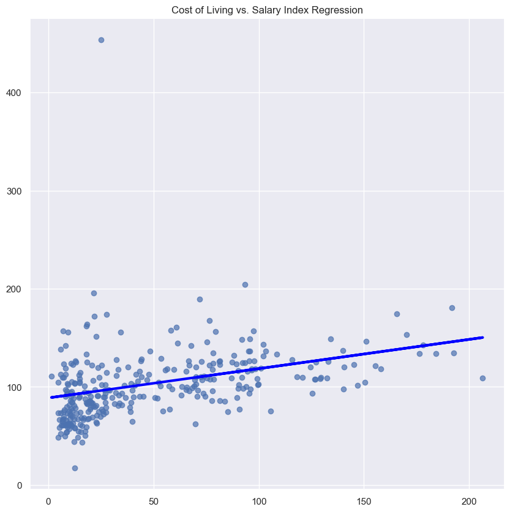

```
Intercept:
 88.79133815114294
Slope:
 0.2978521858344122
```

```python
# Creating Train and Test sets
X_train, X_test, y_train, y_test = train_test_split(index_df['salary_index'], index_df['CoL_index'])
# Fitting to Linear Regression
reg = LinearRegression().fit(X_train.to_numpy().reshape(-1, 1), y_train.values)
# Creating Prediction values
pred = reg.predict(X_test.to_numpy().reshape(-1, 1))
# Creating Plot from predicted data data
plt.plot(X_test, pred, color="blue", linewidth=3)
plt.scatter(X_test,y_test,alpha=.7)
plt.title("Cost of Living vs. Salary Index Regression")
plt.show()
# Printing Y-intercept
print("Intercept: \n", reg.intercept_)
# Printing Slope/Coefficient
print("Slope: \n", reg.coef_[0])
```

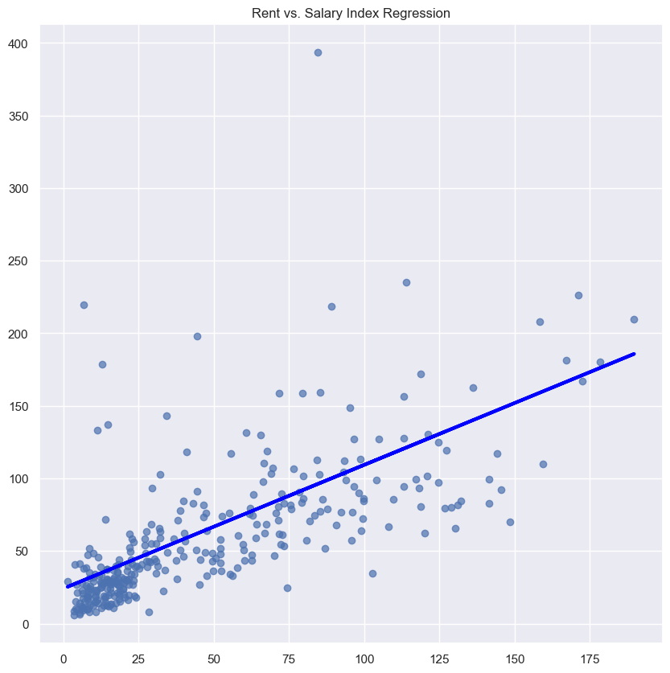

```
Intercept:
 24.103242949384352
Slope:
 0.8520713096164272
```

```python
# Creating Train and Test sets
X_train, X_test, y_train, y_test = train_test_split(index_df['salary_index'], index_df['rent_index'])
# Fitting to Linear Regression
reg = LinearRegression().fit(X_train.to_numpy().reshape(-1, 1), y_train.values)
# Creating Prediction values
pred = reg.predict(X_test.to_numpy().reshape(-1, 1))
# Creating Plot from predicted data data
plt.plot(X_test, pred, color="blue", linewidth=3)
plt.scatter(X_test,y_test,alpha=.7)
plt.title("Rent vs. Salary Index Regression")
plt.show()
# Printing Y-intercept
print("Intercept: \n", reg.intercept_)
# Printing Slope/Coefficient
print("Slope: \n", reg.coef_[0])
```

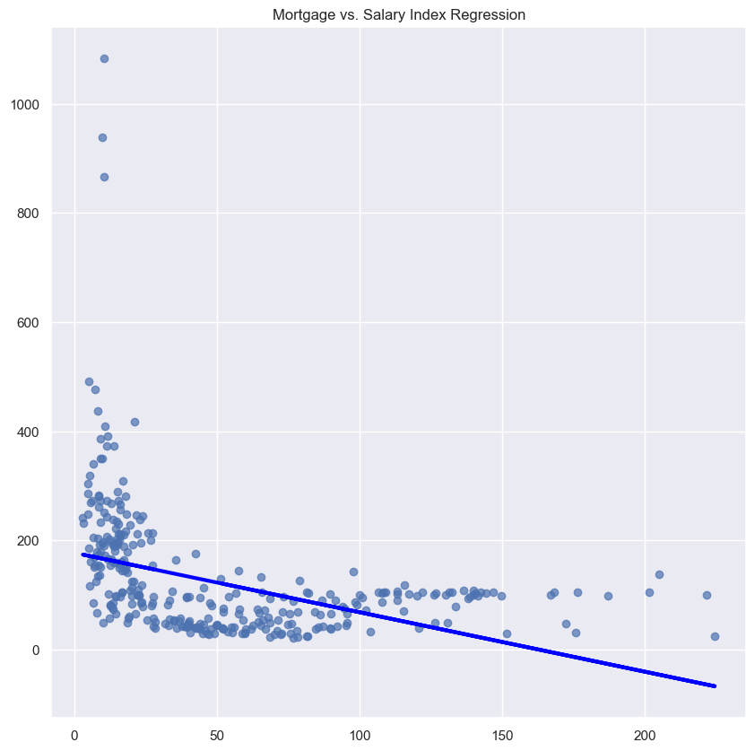

```
Intercept:
 176.96723778230313
Slope:
 -1.0897788361301972
```

```python
# Creating Train and Test sets
X_train, X_test, y_train, y_test = train_test_split(index_df['salary_index'], index_df['mortgage_index'])
# Fitting to Linear Regression
reg = LinearRegression().fit(X_train.to_numpy().reshape(-1, 1), y_train.values)
# Creating Prediction values
pred = reg.predict(X_test.to_numpy().reshape(-1, 1))
# Creating Plot from predicted data data
plt.plot(X_test, pred, color="blue", linewidth=3)
plt.scatter(X_test,y_test,alpha=.7)
plt.title("Mortgage vs. Salary Index Regression")
plt.show()
# Printing Y-intercept
print("Intercept: \n", reg.intercept_)
# Printing Slope/Coefficient
print("Slope: \n", reg.coef_[0])
```

Above we have our reggression model. We can see that our intercept and slop values match what was found from the OLS regression.

### Random Forest Regression

Next we will be using Random Forests.

Random Forest is an algorithm that uses a modified tree learning algorithm that inspects, at each split in the learning process, a random subset of the features. We will be using Random Search with 10-Fold Cross Validation.

We can use a Random Forest Model to explore future trends. We can use Random Forest to further explore the relationship between the salary_index and the mortgage index.

```python
# Random forest Regression
# Split the data into training/testing data using a 80:20 split
X_train, X_test, y_train, y_test = train_test_split(index_df['salary_index'].to_numpy().reshape(-1, 1), index_df['mortgage_index'])

# Tunning of hyper paramemters
# We will be using RandomizedSearchCV with 10-fold cross-validation
# Number of trees in random forest
n_estimators = [int(x) for x in np.linspace(start = 200, stop = 2000, num = 10)]
# Number of features to consider at every split
max_features = ['auto', 'sqrt']
# Maximum number of levels in tree
max_depth = [int(x) for x in np.linspace(10, 110, num = 11)]
max_depth.append(None)
# Minimum number of samples required to split a node
min_samples_split = [2, 5, 10]
# Minimum number of samples required at each leaf node
min_samples_leaf = [1, 2, 4]
# Method of selecting samples for training each tree
bootstrap = [True, False]

# Create the random grid
random_grid = {'n_estimators': n_estimators,
               'max_features': max_features,
               'max_depth': max_depth,
               'min_samples_split': min_samples_split,
               'min_samples_leaf': min_samples_leaf,
               'bootstrap': bootstrap}
print(random_grid)
rf = RandomizedSearchCV(estimator = RandomForestRegressor(), param_distributions = random_grid, cv = 10, verbose=2, n_jobs = 4)
rf.fit(X_train, y_train)
print(rf.best_params_)

# Create set of predicted values based on the test data
pred = rf.predict(X_test)

# Check Mean Absolute Error
errors = abs(pred - y_test)
print('Mean Absolute Error: {:0.4f} degrees.'.format(np.mean(errors)))

# Check Mean Squared Error
mse = mean_squared_error(y_test, pred)
print('Mean Squared Error: {:0.4f} degrees.'.format(mse))

# Check R-squared Score
r2 = r2_score(y_test, pred)
print('R-squared Score: {:0.4f}'.format(r2))
```

```
{'n_estimators': [200, 400, 600, 800, 1000, 1200, 1400, 1600, 1800, 2000], 'max_features': ['auto', 'sqrt'], 'max_depth': [10, 20, 30, 40, 50, 60, 70, 80, 90, 100, 110, None], 'min_samples_split': [2, 5, 10], 'min_samples_leaf': [1, 2, 4], 'bootstrap': [True, False]}
Fitting 10 folds for each of 10 candidates, totalling 100 fits
{'n_estimators': 1600, 'min_samples_split': 5, 'min_samples_leaf': 4, 'max_features': 'sqrt', 'max_depth': 50, 'bootstrap': True}
Mean Absolute Error: 59.3699 degrees.
Mean Squared Error: 10950.4399 degrees.
R-squared Score: 0.2473
```

After the regression we see that we have an MAE of 59.3699, MSE of 10950.4399, and a R-squared score of 0.2473

This tells us that on average the Random Forest model's predictions are off by about 59 degrees of the index. Both the Mean Absolute Error and the Mean Squared Error are sensitive to outliers, we can see from our previous scatter plots above that the mortgage_index has some extreme outliers whcih could be the cause of the high variability.

The R-squared score of 0.2473 tells us that the regression model fits 24.73% of the data's variability in mortgage_index.

We can attempt to handle the outliers in the mortgage_index. Below we can see that there are 6 extreme outliers in the mortgage_index.

```python
index_df.sort_values('mortgage_index', ascending=False)
```

|  | city | country | salary_index | mortgage_index | CoL_index | rent_index |
| --- | --- | --- | --- | --- | --- | --- |
| 792 | Mar del Plata | Argentina | 10.342809 | 1083.815029 | 85.646180 | 28.357122 |
| 333 | Cordoba | Argentina | 14.770754 | 963.391137 | 108.262105 | 19.910429 |
| 2402 | San Carlos de Bariloche | Argentina | 9.899590 | 939.306358 | 122.293573 | 48.592691 |
| 2360 | Mendoza | Argentina | 12.250318 | 879.961464 | 93.545661 | 18.288204 |
| 367 | Rosario | Argentina | 10.371093 | 867.052023 | 91.956855 | 20.582489 |
| ... | ... | ... | ... | ... | ... | ... |
| 3742 | Benidorm | Spain | 38.298968 | 19.267823 | 88.050161 | 49.320298 |
| 33 | Nagoya | Japan | 69.130816 | 19.267823 | 101.104659 | 103.591368 |
| 3681 | Kortrijk | Belgium | 53.559044 | 19.267823 | 100.664549 | 63.482799 |
| 585 | Setagaya | Japan | 48.434168 | 16.955684 | 96.196133 | 151.946953 |
| 2148 | Jyvaskyla | Finland | 72.723519 | 15.414258 | 109.614156 | 62.094387 |

1278 rows × 6 columns

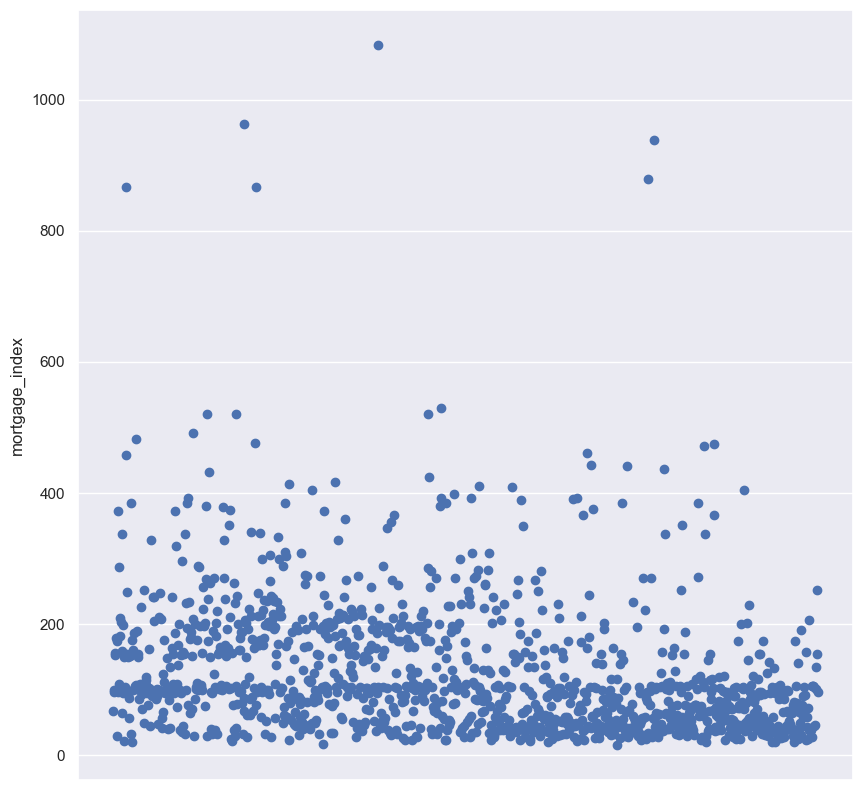

```python
fig, ax = plt.subplots()
ax.scatter(index_df['city'], index_df['mortgage_index'])
plt.ylabel("mortgage_index")
ax = plt.gca()
ax.get_xaxis().set_visible(False)
plt.show()
```

We can attempt to handle these outliers by removing them. However this comes at the cost of possibly removing the applicability of the model to real life.

We can see that all six of the outliers come from Argentina, from this we could conclude that the mortage_index of Argentina is significantly different from the remainder of the data points for the mortage_index.

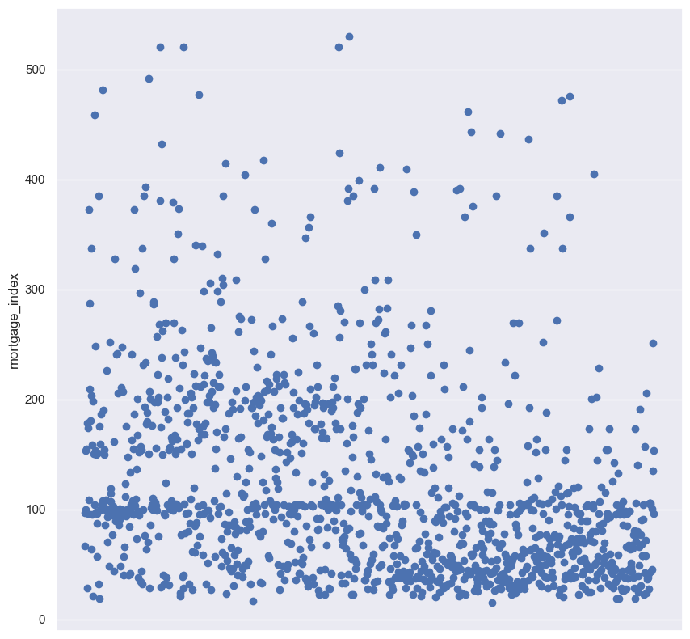

```python
index_df_rf = index_df
index_df_rf.drop(792, inplace=True)
index_df_rf.drop(333, inplace=True)
index_df_rf.drop(2402, inplace=True)
index_df_rf.drop(2360, inplace=True)
index_df_rf.drop(23, inplace=True)
index_df_rf.drop(367, inplace=True)

fig, ax = plt.subplots()
ax.scatter(index_df_rf['city'], index_df_rf['mortgage_index'])
plt.ylabel("mortgage_index")
ax = plt.gca()
ax.get_xaxis().set_visible(False)
plt.show()
```

```python
# Random forest Regression
# Split the new data into training/testing data using a 80:20 split
X_train, X_test, y_train, y_test = train_test_split(index_df_rf['salary_index'].to_numpy().reshape(-1, 1), index_df_rf['mortgage_index'])

# Tunning of hyper paramemters
# We will be using RandomizedSearchCV with 10-fold cross-validation
# Number of trees in random forest
n_estimators = [int(x) for x in np.linspace(start = 200, stop = 2000, num = 10)]
# Number of features to consider at every split
max_features = ['auto', 'sqrt']
# Maximum number of levels in tree
max_depth = [int(x) for x in np.linspace(10, 110, num = 11)]
max_depth.append(None)
# Minimum number of samples required to split a node
min_samples_split = [2, 5, 10]
# Minimum number of samples required at each leaf node
min_samples_leaf = [1, 2, 4]
# Method of selecting samples for training each tree
bootstrap = [True, False]

# Create the random grid
random_grid = {'n_estimators': n_estimators,
               'max_features': max_features,
               'max_depth': max_depth,
               'min_samples_split': min_samples_split,
               'min_samples_leaf': min_samples_leaf,
               'bootstrap': bootstrap}
print(random_grid)
rf = RandomizedSearchCV(estimator = RandomForestRegressor(), param_distributions = random_grid, cv = 10, verbose=2, n_jobs = 4)
rf.fit(X_train, y_train)
print(rf.best_params_)

# Create set of predicted values based on the test data
pred = rf.predict(X_test)

# Check Mean Absolute Error
errors = abs(pred - y_test)
print('Mean Absolute Error: {:0.4f} degrees.'.format(np.mean(errors)))

# Check Mean Squared Error
mse = mean_squared_error(y_test, pred)
print('Mean Squared Error: {:0.4f} degrees.'.format(mse))

# Check R-squared Score
r2 = r2_score(y_test, pred)
print('R-squared Score: {:0.4f}'.format(r2))
```

```
{'n_estimators': [200, 400, 600, 800, 1000, 1200, 1400, 1600, 1800, 2000], 'max_features': ['auto', 'sqrt'], 'max_depth': [10, 20, 30, 40, 50, 60, 70, 80, 90, 100, 110, None], 'min_samples_split': [2, 5, 10], 'min_samples_leaf': [1, 2, 4], 'bootstrap': [True, False]}
Fitting 10 folds for each of 10 candidates, totalling 100 fits
{'n_estimators': 1800, 'min_samples_split': 10, 'min_samples_leaf': 4, 'max_features': 'sqrt', 'max_depth': 90, 'bootstrap': True}
Mean Absolute Error: 45.5681 degrees.
Mean Squared Error: 4502.8182 degrees.
R-squared Score: 0.4207
```

After building the Random Forest model on the new data we see that we have an MAE of 45.5681, MSE of 4502.8182, and a R-squared score of 0.4207.

The R-squared Score has improved with the removal of the outliers and the Mean Absolute Error and Mean Squared Error have both shrunk considerably as expected after removing the extreme data points.

## K Nearest Neighbor Regression

Lastly we will be doing K nearest neighbor regression.

KNN is an algorithm that approximates the association between parameters.

We will be using Random Search with 10-Fold Cross Validation here as well.

```python
# KNN Regression
# Split the new data into training/testing data using a 80:20 split
X_train, X_test, y_train, y_test = train_test_split(index_df['salary_index'].to_numpy().reshape(-1, 1), index_df['mortgage_index'])

knn_grid = {'n_neighbors':[3,5,11,19], 'weights':['uniform', 'distance'],
 'metric':['euclidean', 'manhattan']}
knn = RandomizedSearchCV(KNeighborsRegressor(), param_distributions = knn_grid, cv = 10, verbose=2, n_jobs = 4)
knn.fit(X_train, y_train)
print('Score: {:0.4f}'.format(knn.score(X_test, y_test)))
```

```
Fitting 10 folds for each of 10 candidates, totalling 100 fits
Score: 0.4230
```

After the K Nearest Neighbor regression we see that we have a score of 0.4230

The KNN score allows us to see the mean accuracy of the model. This tells us that the regression model fits 42.30% of the data's variability in mortgage_index.

```python
# KNN Regression
# Split the new data into training/testing data using a 80:20 split
X_train, X_test, y_train, y_test = train_test_split(index_df_rf['salary_index'].to_numpy().reshape(-1, 1), index_df_rf['mortgage_index'])

knn_grid = {'n_neighbors':[3,5,11,19], 'weights':['uniform', 'distance'],
 'metric':['euclidean', 'manhattan']}
knn = RandomizedSearchCV(KNeighborsRegressor(), param_distributions = knn_grid, cv = 10, verbose=2, n_jobs = 4)
knn.fit(X_train, y_train)
print('Score: {:0.4f}'.format(knn.score(X_test, y_test)))
```

```
Fitting 10 folds for each of 10 candidates, totalling 100 fits
Score: 0.5446
```

After the K Nearest Neighbor regression, we see that we have a score of 0.5446.

The KNN score allows us to see the mean accuracy of the model. This tells us that the regression model fits 54.46% of the data's variability in mortgage_index.

After removing the outliers, we see that the KNN model has a moderate score. This could be attributed to the naturally high variability between the data points of the salary_index and the mortgage_index.

## 6. Insights and Final Comments

From our analysis, we have found that there is a statistically significant correlation between salary and the cost of living, rent, and mortgage. The data also suggests that there is a linear relationship between Salary and these three parameters.

We observed that the cost of living increases proportionally with a rate of 0.2978 USD per unit increase in salary. The rent also increases proportionally with a rate of 0.8520 USD per unit increase in salary. However, the mortgage decreases proportionally with a rate of 1.0897 USD per unit increase in salary.

Based on the data gathered, we do not support that there is a Global Cost of Living Crisis for the time being. However, the predictive models are unable to capture the full variation of the data due to the high variability of the data and the existence of extreme outliers. These outliers suggest that instead there are significantly different costs of living conditions between countries.